# Heart Disease Classification

Logistic Regression, kNN, Decision Tree, & Naive Bayes

[figure not shown]

# Introduction

Did you know? someone has a heart attack every 40 seconds in the United States. And in the same region, about 647,000 people die from heart disease every year. Heart disease is the leading cause of death for men, women, and people of most racial and ethnic groups until now.

In this project, we want to analyze about the cause of heart attack and also we want to create a model that can be useful to predict the heart disease event. The dataset that we’re going to use is the *Heart Disease Data Set* from [UCI Machine Learning Repository](https://archive.ics.uci.edu/ml/datasets/Heart+Disease). In which the patients data itself was collected from **Cleveland, Hungary, Switzerland, and Long Beach**.

To summarize our objectives, here are what we’re going to do in this dataset:

- Deep **Exploratory Data Analysis** on our independent and dependent variables.
- Create **Machine Learning** models.
- Perform **prediction** on unseen data using our models.
- **Evaluate** our models performance.
- **Choose the best model**.

# Understanding our Data

Before we’re doing our Exploratory Data Analysis, we will examine our dataset first to see if there are any anomalies that we can fix within the dataset. It is important that insights are only as good as the data that informs them. This means it’s vital for the data to be clean and in the shape of usable form.

## Table Preview

```r
heart <- read.csv("heart.csv")
rmarkdown::paged_table(heart)
```

| Age | Sex | ChestPainType | RestingBP | Cholesterol | FastingBS | RestingECG | MaxHR | ExerciseAngina | Oldpeak | ST_Slope | HeartDisease |
| --- | --- | --- | --- | --- | --- | --- | --- | --- | --- | --- | --- |
| 40 | M | ATA | 140 | 289 | 0 | Normal | 172 | N | 0.0 | Up | 0 |
| 49 | F | NAP | 160 | 180 | 0 | Normal | 156 | N | 1.0 | Flat | 1 |
| 37 | M | ATA | 130 | 283 | 0 | ST | 98 | N | 0.0 | Up | 0 |
| 48 | F | ASY | 138 | 214 | 0 | Normal | 108 | Y | 1.5 | Flat | 1 |
| 54 | M | NAP | 150 | 195 | 0 | Normal | 122 | N | 0.0 | Up | 0 |
| 39 | M | NAP | 120 | 339 | 0 | Normal | 170 | N | 0.0 | Up | 0 |
| 45 | F | ATA | 130 | 237 | 0 | Normal | 170 | N | 0.0 | Up | 0 |
| 54 | M | ATA | 110 | 208 | 0 | Normal | 142 | N | 0.0 | Up | 0 |
| 37 | M | ASY | 140 | 207 | 0 | Normal | 130 | Y | 1.5 | Flat | 1 |
| 48 | F | ATA | 120 | 284 | 0 | Normal | 120 | N | 0.0 | Up | 0 |

[output cut: 908 more lines]

## Data Wrangling

- Check the **data types**:

```r
glimpse(heart)
```

```
## Rows: 918
## Columns: 12
## $ Age            <int> 40, 49, 37, 48, 54, 39, 45, 54, 37, 48, 37, 58, 39, 49,…
## $ Sex            <chr> "M", "F", "M", "F", "M", "M", "F", "M", "M", "F", "F", …
## $ ChestPainType  <chr> "ATA", "NAP", "ATA", "ASY", "NAP", "NAP", "ATA", "ATA",…
## $ RestingBP      <int> 140, 160, 130, 138, 150, 120, 130, 110, 140, 120, 130, …
## $ Cholesterol    <int> 289, 180, 283, 214, 195, 339, 237, 208, 207, 284, 211, …
## $ FastingBS      <int> 0, 0, 0, 0, 0, 0, 0, 0, 0, 0, 0, 0, 0, 0, 0, 0, 0, 0, 0…
## $ RestingECG     <chr> "Normal", "Normal", "ST", "Normal", "Normal", "Normal",…
## $ MaxHR          <int> 172, 156, 98, 108, 122, 170, 170, 142, 130, 120, 142, 9…
## $ ExerciseAngina <chr> "N", "N", "N", "Y", "N", "N", "N", "N", "Y", "N", "N", …
## $ Oldpeak        <dbl> 0.0, 1.0, 0.0, 1.5, 0.0, 0.0, 0.0, 0.0, 1.5, 0.0, 0.0, …
## $ ST_Slope       <chr> "Up", "Flat", "Up", "Flat", "Up", "Up", "Up", "Up", "Fl…
## $ HeartDisease   <int> 0, 1, 0, 1, 0, 0, 0, 0, 1, 0, 0, 1, 0, 1, 0, 0, 1, 0, 1…
```

As demonstrated above, our variables data types are still not in the right type. * Change the **data types**:

```r
heart <-
  heart %>%
  mutate_at(vars(Sex, ChestPainType, FastingBS, RestingECG, ExerciseAngina, ST_Slope), as.factor) %>%
  mutate(Sex = case_when(
    Sex == "M" ~ "Male",
    Sex == "F" ~ "Female"),
    FastingBS = case_when(
    FastingBS == "0" ~ "< 120 mg/dl",
    FastingBS == "1" ~ "> 120 mg/dl"),
    ExerciseAngina = case_when(
    ExerciseAngina == "N" ~ "No",
    ExerciseAngina == "Y" ~ "Yes"))
```

- Check for **missing values**:

```r
colSums(is.na(heart))
```

```
##            Age            Sex  ChestPainType      RestingBP    Cholesterol
##              0              0              0              0              0
##      FastingBS     RestingECG          MaxHR ExerciseAngina        Oldpeak
##              0              0              0              0              0
##       ST_Slope   HeartDisease
##              0              0
```

There are no missing values within our dataset.

# Exploratory Data Analysis

Exploratory data analysis (EDA) involves using graphics and visualizations to explore and analyze a data set. The goal is to explore, investigate and learn the data variables within our dataset.

## Categorical Variables Distribution

From the inspection on **Data Wrangling** step earlier, these are all our *categorical variables* and their distribution:

### Chest Pain

```r
heart_cp <-
  heart %>%
  select(ChestPainType) %>%
  group_by(ChestPainType) %>%
  summarize(total = n()) %>%
  ungroup() %>%
  arrange(desc(-total))

heart_cp %>%
  e_charts(x = ChestPainType) %>%
  e_pie(total,
        roseType = "radius",
        itemStyle = list(
          color = htmlwidgets::JS("
          function(params) {
                                var colorList = [new echarts.graphic.LinearGradient(
                                                 1, 0, 0, 0,
                                                [
                                                 { offset: 0, color: '#FFE5DB' },
                                                 { offset: 1, color: '#FFE5DB' }
                                                ]),
                                                new echarts.graphic.LinearGradient(
                                                 0, 0, 0, 1,
                                                [
                                                 { offset: 0, color: '#FFE5DB' },
                                                 { offset: 1, color: '#FFE5DB' }
                                                ]),
                                                new echarts.graphic.LinearGradient(
                                                 0, 0, 0, 1,
                                                [
                                                 { offset: 0, color: '#FFE5DB' },
                                                 { offset: 1, color: '#E08F83' }
                                                ]),
                                                new echarts.graphic.LinearGradient(
                                                 0, 0, 0, 1,
                                                [
                                                 { offset: 0, color: '#FB6A63' },
                                                 { offset: 1, color: '#B83F3E' }
                                                ])];
                                return colorList[params.dataIndex]
                                }

        ")),
        radius = c("25%", "70%"),
        legend= FALSE,
        label = list(
          color = "#DFC18F",
          fontFamily = "Cardo",
          fontSize = 14
        ),
        animationDuration = 4000) %>%
  e_title(text = "Chest Pain Distribution",
          textStyle = list(
            color = "#DFC18F",
            fontStyle = "italic"
          ),
          right = "10%",
          left = "50%") %>%
  e_tooltip(formatter = htmlwidgets::JS("
                                        function(params)
                                        {
                                            return `<strong style='color:White;'>Count:</strong> ${params.value}
                                                    <br/><strong style='color:White;'>Percent:</strong> ${params.percent}%`
                                        }  ")) %>%
  e_theme_custom("rangga3.json")
```

[interactive chart not shown]

★ **ASY** takes the majority of the `ChestPainType` distribution. (54.03%)

★ **ASY** stands for *Asymptomatic* which means no symptoms or when a patient have an illness or condition (such as early stage high blood pressure or glaucoma) but do not have symptoms of it.

### Gender

```r
heart_sex <-
  heart %>%
  select(Sex) %>%
  group_by(Sex) %>%
  summarize(total = n()) %>%
  ungroup() %>%
  arrange(desc(-total))

heart_sex %>%
  e_charts(x = Sex) %>%
  e_pie(total,
        roseType = "radius",
        itemStyle = list(
          color = htmlwidgets::JS("
          function(params) {
                                var colorList = [new echarts.graphic.LinearGradient(
                                                 0, 0, 0, 1,
                                                [
                                                 { offset: 0, color: '#FFE5DB' },
                                                 { offset: 1, color: '#E08F83' }
                                                ]),
                                                new echarts.graphic.LinearGradient(
                                                 0, 0, 0, 1,
                                                [
                                                 { offset: 0, color: '#FB6A63' },
                                                 { offset: 1, color: '#B83F3E' }
                                                ])];
                                return colorList[params.dataIndex]
                                }

    ")),
        radius = c("25%", "70%"),
        legend= FALSE,
        label = list(
          color = "#DFC18F",
          fontFamily = "Cardo",
          fontSize = 14
        ),
        animationDuration = 4000) %>%
  e_title(text = "Gender Distribution",
          textStyle = list(
            color = "#DFC18F",
            fontStyle = "italic"
          ),
          right = "10%",
          left = "50%",
          top = "1%") %>%
  e_tooltip(formatter = htmlwidgets::JS("
                                        function(params)
                                        {
                                            return `<strong style='color:White;'>Count:</strong> ${params.value}
                                                    <br/><strong style='color:White;'>Percent:</strong> ${params.percent}%`
                                        }  ")) %>%
  e_theme_custom("rangga1.json")
```

[interactive chart not shown]

★ **Male** patient takes the majority of the `Sex` distribution. (78.98%)

### Fasting Blood Sugar

```r
heart_fbs <-
  heart %>%
  select(FastingBS) %>%
  group_by(FastingBS) %>%
  summarize(total = n()) %>%
  ungroup() %>%
  arrange(desc(-total))

heart_fbs %>%
  e_charts(x = FastingBS) %>%
  e_pie(total,
        roseType = "radius",
        itemStyle = list(
          color = htmlwidgets::JS("
          function(params) {
                                var colorList = [new echarts.graphic.LinearGradient(
                                                 0, 0, 0, 1,
                                                [
                                                 { offset: 0, color: '#FFE5DB' },
                                                 { offset: 1, color: '#E08F83' }
                                                ]),
                                                new echarts.graphic.LinearGradient(
                                                 0, 0, 0, 1,
                                                [
                                                 { offset: 0, color: '#FB6A63' },
                                                 { offset: 1, color: '#B83F3E' }
                                                ])];
                                return colorList[params.dataIndex]
                                }

    ")),
        radius = c("25%", "70%"),
        legend= FALSE,
        label = list(
          color = "#DFC18F",
          fontFamily = "Cardo",
          fontSize = 14
        ),
        animationDuration = 4000) %>%
  e_title(text = "Fasting Blood Sugar Distribution",
          textStyle = list(
            color = "#DFC18F",
            fontStyle = "italic"
          ),
          right = "10%",
          left = "50%",
          top = "1%") %>%
  e_tooltip(formatter = htmlwidgets::JS("
                                        function(params)
                                        {
                                            return `<strong style='color:White;'>Count:</strong> ${params.value}
                                                    <br/><strong style='color:White;'>Percent:</strong> ${params.percent}%`
                                        }  ")) %>%
  e_theme_custom("rangga1.json")
```

[interactive chart not shown]

★ A fasting blood sugar level less than 100 mg/dL (5.6 mmol/L) is considered **normal**.

★ A fasting blood sugar level from 100 to 125 mg/dL (5.6 to 6.9 mmol/L) is considered **pre-diabetes**.

★ If it’s 126 mg/dL (7 mmol/L) or higher on two separate tests, means a person have **diabetes**.

★ Majority of patients still have **normal** and **pre-diabetes** conditions. (76.69%)

### Resting ECG

```r
heart_rtcg <-
  heart %>%
  select(RestingECG) %>%
  group_by(RestingECG) %>%
  summarize(total = n()) %>%
  ungroup() %>%
  arrange(desc(-total))

heart_rtcg %>%
  e_charts(x = RestingECG) %>%
  e_pie(total,
        roseType = "radius",
        itemStyle = list(
          color = htmlwidgets::JS("
          function(params) {
                                var colorList = [new echarts.graphic.LinearGradient(
                                                 0, 0, 0, 1,
                                                [
                                                 { offset: 0, color: '#FFE5DB' },
                                                 { offset: 1, color: '#FFE5DB' }
                                                ]),
                                                new echarts.graphic.LinearGradient(
                                                 0, 0, 0, 1,
                                                [
                                                 { offset: 0, color: '#FFE5DB' },
                                                 { offset: 1, color: '#E08F83' }
                                                ]),
                                                new echarts.graphic.LinearGradient(
                                                 0, 0, 0, 1,
                                                [
                                                 { offset: 0, color: '#FB6A63' },
                                                 { offset: 1, color: '#B83F3E' }
                                                ])];
                                return colorList[params.dataIndex]
                                }

        ")),
        radius = c("25%", "70%"),
        legend= FALSE,
        label = list(
          color = "#DFC18F",
          fontFamily = "Cardo",
          fontSize = 14
        ),
        animationDuration = 4000) %>%
  e_title(text = "Resting Electrocardiogram Distribution",
          textStyle = list(
            color = "#DFC18F",
            fontStyle = "italic"
          ),
          right = "10%",
          left = "50%",
          top = "1%") %>%
  e_tooltip(formatter = htmlwidgets::JS("
                                        function(params)
                                        {
                                            return `<strong style='color:White;'>Count:</strong> ${params.value}
                                                    <br/><strong style='color:White;'>Percent:</strong> ${params.percent}%`
                                        }  ")) %>%
  e_theme_custom("rangga1.json")
```

[interactive chart not shown]

★ **Normal**: your Heart rate and Rythm is normal and consistent.

★ **ST**: T wave inversions and/or ST elevation or depression of more than 0.05 mV.

★ **LVH**: showing probable or definite left ventricular hypertrophy by Estes’ criteria.

★ Most of people still have a **Normal** `RestingECG` results. (60.13%)

### ST Slope

```r
heart_slp <-
  heart %>%
  select(ST_Slope) %>%
  group_by(ST_Slope) %>%
  summarize(total = n()) %>%
  ungroup() %>%
  arrange(desc(-total))

heart_slp %>%
  e_charts(x = ST_Slope) %>%
  e_pie(total,
        roseType = "radius",
        itemStyle = list(
          color = htmlwidgets::JS("
          function(params) {
                                var colorList = [new echarts.graphic.LinearGradient(
                                                 0, 0, 0, 1,
                                                [
                                                 { offset: 0, color: '#FFE5DB' },
                                                 { offset: 1, color: '#FFE5DB' }
                                                ]),
                                                new echarts.graphic.LinearGradient(
                                                 0, 0, 0, 1,
                                                [
                                                 { offset: 0, color: '#FFE5DB' },
                                                 { offset: 1, color: '#E08F83' }
                                                ]),
                                                new echarts.graphic.LinearGradient(
                                                 0, 0, 0, 1,
                                                [
                                                 { offset: 0, color: '#FB6A63' },
                                                 { offset: 1, color: '#B83F3E' }
                                                ])];
                                return colorList[params.dataIndex]
                                }

        ")),
        radius = c("25%", "70%"),
        legend= FALSE,
        label = list(
          color = "#DFC18F",
          fontFamily = "Cardo",
          fontSize = 14
        ),
        animationDuration = 4000) %>%
  e_title(text = "ST Slope Distribution",
          textStyle = list(
            color = "#DFC18F",
            fontStyle = "italic"
          ),
          right = "10%",
          left = "50%",
          top = "1%") %>%
  e_tooltip(formatter = htmlwidgets::JS("
                                        function(params)
                                        {
                                            return `<strong style='color:White;'>Count:</strong> ${params.value}
                                                    <br/><strong style='color:White;'>Percent:</strong> ${params.percent}%`
                                        }  ")) %>%
  e_theme_custom("rangga1.json")
```

[interactive chart not shown]

★ Up/**Upslopping**: upsloping ST‐segment depression is associated with an increased risk of coronary artery disease.

★ Down/**Downsloping**: downsloping ST-segment depression is a common manifestation of severe myocardial ischemia.

★ **Flat**: The normal ST-segment is flat and isoelectric.

★ The patient distribution for **Flat** and **Upslopping** `ST-Slope` are pretty even< (50% vs 43%) while **Downsloping** `ST-Slope` takes the minority role. (only 7%)

### Exercise Angina

```r
heart_exng <-
  heart %>%
  select(ExerciseAngina) %>%
  group_by(ExerciseAngina) %>%
  summarize(total = n()) %>%
  ungroup() %>%
  arrange(desc(-total))

heart_exng %>%
  e_charts(x = ExerciseAngina) %>%
  e_pie(total,
        roseType = "radius",
        itemStyle = list(
          color = htmlwidgets::JS("
          function(params) {
                                var colorList = [new echarts.graphic.LinearGradient(
                                                 0, 0, 0, 1,
                                                [
                                                 { offset: 0, color: '#FFE5DB' },
                                                 { offset: 1, color: '#E08F83' }
                                                ]),
                                                new echarts.graphic.LinearGradient(
                                                 0, 0, 0, 1,
                                                [
                                                 { offset: 0, color: '#FB6A63' },
                                                 { offset: 1, color: '#B83F3E' }
                                                ])];
                                return colorList[params.dataIndex]
                                }

    ")),
        radius = c("25%", "70%"),
        legend= FALSE,
        label = list(
          color = "#DFC18F",
          fontFamily = "Cardo",
          fontSize = 14
        ),
        animationDuration = 4000) %>%
    e_title(text = "Exercise Angina Distribution",
          textStyle = list(
            color = "#DFC18F",
            fontStyle = "italic"
          ),
          right = "10%",
          left = "50%",
          top = "1%") %>%
  e_tooltip(formatter = htmlwidgets::JS("
                                        function(params)
                                        {
                                            return `<strong style='color:White;'>Count:</strong> ${params.value}
                                                    <br/><strong style='color:White;'>Percent:</strong> ${params.percent}%`
                                        }  ")) %>%
  e_theme_custom("rangga1.json")
```

[interactive chart not shown]

★ `ExerciseAngina` is a pain in the chest that comes on with exercise, stress, or other things that make the heart work harder.

★ The distributions are pretty even for the people who having an **angina or not**. (60% vs 40%)

## Numerical Variables Distribution

Before we go into the data distribution, we will be analyzing the **Pearson Correlation** between all of our numerical variables first to see if there any initial multicollinearity.

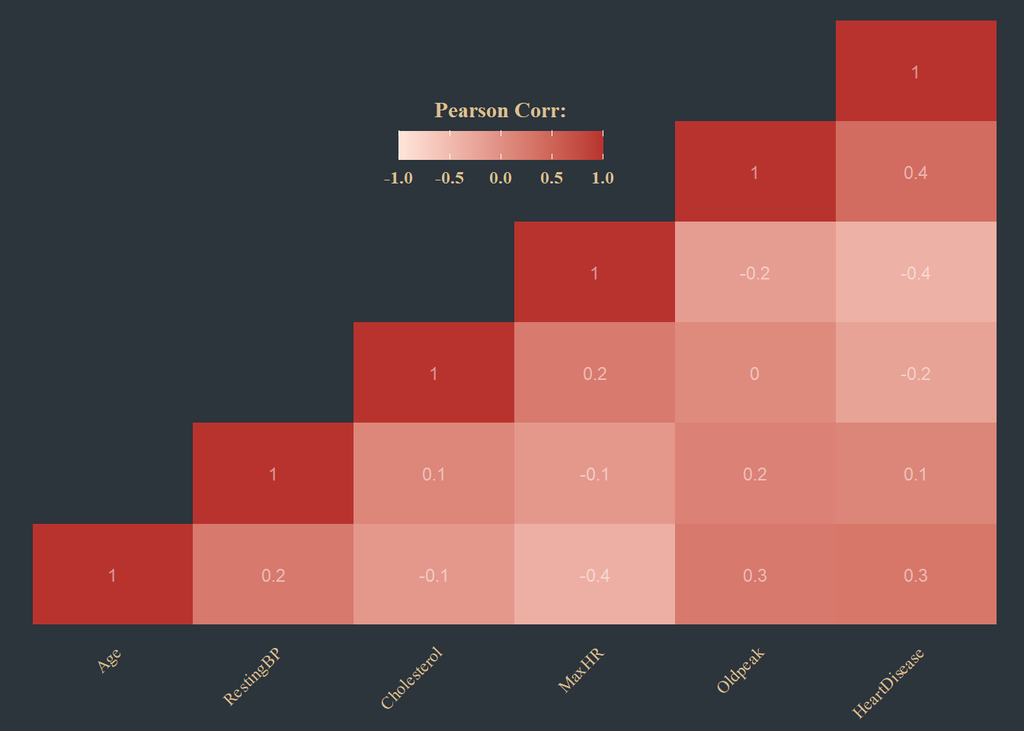

```r
heart_num <- heart %>%
  select(Age, RestingBP, Cholesterol, MaxHR, Oldpeak, HeartDisease)

cormat <- round(cor(heart_num),2)

get_lower_tri<-function(cormat){
  cormat[upper.tri(cormat)] <- NA
  return(cormat)
  }

get_upper_tri <- function(cormat){
  cormat[lower.tri(cormat)]<- NA
  return(cormat)
}

lower_tri <- get_lower_tri(cormat)

heart_cor_melt <- reshape2::melt(lower_tri, na.rm = TRUE)
heart_cor_melt <- heart_cor_melt %>%
  mutate(label = glue("{Var1} ~ {Var2}"))

ggplot(heart_cor_melt,aes(Var1, Var2, text = label)) +
  geom_tile(aes(fill = value)) +
  geom_text(aes(label = round(value, 1)), alpha=0.5, size = 3, color = "White") +
  scale_fill_gradientn(colors = c("#FFE5DB","#E08F83","#B8332E"),
                      values = rescale(c(-1,0,1)),
                      limits = c(-1,1)) +
  labs(x = NULL,
      y = NULL,
      fill = "Pearson Corr:") +
  theme(legend.background = element_rect(fill = "#2C343C", color = "#2C343C"),
        plot.background = element_rect(fill = "#2C343C", color = "#2C343C"),
        panel.background = element_rect(fill = "#2C343C"),
        panel.grid = element_line(colour = "#2C343C"),
        panel.grid.major.x = element_line(colour = "#2C343C"),
        panel.grid.minor.x = element_line(colour = "#2C343C"),
        legend.title = element_text(colour = "#DFC18F", face ="bold", family = "Times New Roman"),
        legend.text = element_text(colour = "#DFC18F", face ="bold", family = "Times New Roman"),
        legend.justification = c(1, 0),
        legend.position = c(0.6, 0.7),
        legend.direction = "horizontal",
        axis.text.x = element_text(color = "#DFC18F", family = "Times New Roman",
                                angle = 45, vjust = 1, hjust = 1),
        axis.text.y = element_blank(),
        axis.ticks = element_blank()) +
        guides(fill = guide_colorbar(barwidth = 7, barheight = 1,
                  title.position = "top", title.hjust = 0.5))
```

As it shows above, there are no multicollinearity detected since the highest score available is between **0.4/-0.4**.

### Age

```
## [1] "Skewness :-0.2"
```

```
## [1] "Kurtosis :2.61"
```

```r
heart_age <- heart %>%
  select(Age) %>%
  pivot_longer(
  Age,
  names_to = "name")

linear_gradient <- htmlwidgets::JS(
  "new echarts.graphic.LinearGradient(
    0, 0, 0, 1,
    [
      { offset: 0, color: '#D76662' },
      { offset: 1, color: '#862421' }
    ])"
)

linear_gradient2 <- htmlwidgets::JS(
  "new echarts.graphic.LinearGradient(
    0, 0, 0, 1,
    [
      { offset: 0, color: '#FFE5DB' },
      { offset: 1, color: '#E08F83' }
    ])"
)


heart_age1 <- heart_age %>%
  e_charts() %>%
  e_boxplot(value, outliers = T, name = "Age",
            boxWidth = c(50, 150),
            itemStyle = list(color = linear_gradient,
                             borderColor = linear_gradient2,
                             borderType = "dashed"),
            animationDuration = 2000) %>%
  e_title(text = "Summary",
          textStyle = list(
            color = "#DFC18F",
            fontStyle = "italic",
            fontFamily = "Cardo",
            fontSize = 22
          ),
          right = "10%",
          left = "40%",
          top = "1%") %>%
  e_x_axis(axisLabel = list(color = "#2C343C"),
           axisLine = list(
             lineStyle = list(
               color = "#333D47"
             )
           )) %>%
  e_y_axis(axisLabel = list(fontFamily = "Cardo", color = "#DFC18F"),
           splitLine = list(
             lineStyle = list(
               color = "#333D47"
             )
           )) %>%
  e_color(background = "#2C343C") %>%
  e_tooltip(trigger = "axis",
            axisPointer = list(
              type = "line",
              label = list(
                backgroundColor = "#2C343C",
                fontFamily = "Cardo",
                color = "#DFC18F"
              ),
              lineStyle = list(
                color = linear_gradient2
              )
            ),
            textStyle = list(
              fontFamily = "Cardo",
              color = "#DFC18F"),
            backgroundColor = "#2C343C",
            borderColor = "#2C343C",
            formatter = htmlwidgets::JS("
                                        function(params)
                                        {
                                            return `<strong style='color:#D76662;'>Age</strong>
                                                    <br/><strong style='color:White;'>Max:</strong> 77
                                                    <br/><strong style='color:White;'>Q3:</strong> 60
                                                    <br/><strong style='color:White;'>Median:</strong> 54
                                                    <br/><strong style='color:White;'>Q1:</strong> 47
                                                    <br/><strong style='color:White;'>Min:</strong> <strong style='color:#D76662;'>28</strong>
                                                    <br/><strong style='color:White;'>Mean:</strong> 53.51`
                                        }  "))


heart_age2 <- heart_age %>%
  e_charts()  %>%
  e_histogram(value,
              legend = F,
              areaStyle = list(opacity = .4,
                               color = linear_gradient2),
              itemStyle = list(color = linear_gradient2)) %>%
  e_density(value,
            areaStyle = list(opacity = .4,
                             color = linear_gradient),
            itemStyle = list(color = linear_gradient,
                             borderType = "dashed"),
            y_index = 1,
            legend = F) %>%
  e_title(text = "Distribution",
          textStyle = list(
            color = "#DFC18F",
            fontStyle = "italic"
          ),
          right = "10%",
          left = "50%",
          top = "1%") %>%
  e_theme_custom("rangga1.json") %>%
  e_animation(duration = 2000) %>%
  e_tooltip(axis = "trigger",
            axisPointer = list(
              type = "cross",
              label = list(
                backgroundColor = "#2C343C",
                fontFamily = "Cardo",
                color = "#DFC18F"
              ),
              crossStyle = list(
                color = linear_gradient2
              )
            ),
            formatter = htmlwidgets::JS("
                                        function(params)
                                        {
                                            return `<strong style='color:White;'>Age:</strong> ${params.value[0]}
                                                    <br/><strong style='color:White;'>Count:</strong> ${params.value[1]}`
                                        }  "))

hw_grid(heart_age1, heart_age2)
```

[interactive chart not shown]

★ The distribution of patient `Age` is quite normal since the curve bear resemblance to a bell curve.

★ **Skewness** and **Kurtosis** are adjacent to **0** and **3** *respectively*.

### Resting Blood Pressure

```
## [1] "Skewness :0.18"
```

```
## [1] "Kurtosis :6.25"
```

```r
heart_rbp <- heart %>%
  select(RestingBP) %>%
  pivot_longer(
  RestingBP,
  names_to = "name")

heart_rbp1 <- heart_rbp %>%
  e_charts() %>%
  e_boxplot(value, outliers = F, name = "RBP",
            boxWidth = c(50, 150),
            itemStyle = list(color = linear_gradient,
                             borderColor = linear_gradient2,
                             borderType = "dashed"),
            animationDuration = 2000) %>%
  e_title(text = "Summary",
          textStyle = list(
            color = "#DFC18F",
            fontStyle = "italic",
            fontFamily = "Cardo",
            fontSize = 22
          ),
          right = "10%",
          left = "40%",
          top = "1%") %>%
  e_x_axis(axisLabel = list(color = "#2C343C"),
           axisLine = list(
             lineStyle = list(
               color = "#333D47"
             )
           )) %>%
  e_y_axis(axisLabel = list(fontFamily = "Cardo",
                            color = "#DFC18F"),
           splitLine = list(
             lineStyle = list(
               color = "#333D47"
             )
           )) %>%
  e_color(background = "#2C343C") %>%
  e_tooltip(trigger = "axis",
            axisPointer = list(
              type = "line",
              label = list(
                backgroundColor = "#2C343C",
                fontFamily = "Cardo",
                color = "#DFC18F"
              ),
              lineStyle = list(
                color = linear_gradient2
              )
            ),
            textStyle = list(
              fontFamily = "Cardo",
              color = "#DFC18F"),
            backgroundColor = "#2C343C",
            borderColor = "#2C343C",
            formatter = htmlwidgets::JS("
                                        function(params)
                                        {
                                            return `<strong style='color:#D76662;'>Blood Pressure</strong>
                                                    <br/><strong style='color:White;'>Max:</strong> 200.0
                                                    <br/><strong style='color:White;'>Q3:</strong> 140.0
                                                    <br/><strong style='color:White;'>Median:</strong> 130.0
                                                    <br/><strong style='color:White;'>Q1:</strong> 120.0
                                                    <br/><strong style='color:White;'>Min:</strong> <strong style='color:#D76662;'>53.51</strong>
                                                    <br/><strong style='color:White;'>Mean:</strong> 132.4`
                                        }  "))


heart_rbp2 <- heart_rbp %>%
  e_charts()  %>%
  e_histogram(value,
              legend = F,
              areaStyle = list(opacity = .4,
                               color = linear_gradient2),
              itemStyle = list(color = linear_gradient2)) %>%
  e_density(value,
            areaStyle = list(opacity = .4,
                             color = linear_gradient),
            itemStyle = list(color = linear_gradient),
            y_index = 1,
            legend = F) %>%
  e_title(text = "Distribution",
          textStyle = list(
            color = "#DFC18F",
            fontStyle = "italic"
          ),
          right = "10%",
          left = "50%",
          top = "1%") %>%
  e_theme_custom("rangga1.json") %>%
  e_animation(duration = 2000) %>%
  e_tooltip(axis = "trigger",
            axisPointer = list(
              type = "cross",
              label = list(
                backgroundColor = "#2C343C",
                fontFamily = "Cardo",
                color = "#DFC18F"
              ),
              crossStyle = list(
                color = linear_gradient2
              )
            ),
            formatter = htmlwidgets::JS("
                                        function(params)
                                        {
                                            return `<strong style='color:White;'>Blood Pressure:</strong> ${params.value[0]}mm/hg
                                                    <br/><strong style='color:White;'>Count:</strong> ${params.value[1]}`
                                        }  "))

hw_grid(heart_rbp1, heart_rbp2)
```

[interactive chart not shown]

★ Majority of the patient’s Blood Pressure are between 110mm/hg - 150mm/hg.

★ This might be because there’s a outliers within `RestingBP` values 0mm/hg - 60mm/hg.

★ **Skewness** are adjacent to **0** while **Kurtosis** are not adjacent to **3**.

### Cholesterol

```
## [1] "Skewness :-0.61"
```

```
## [1] "Kurtosis :3.11"
```

```r
heart_chol <- heart %>%
  select(Cholesterol) %>%
  pivot_longer(
  Cholesterol,
  names_to = "name")

heart_chol1 <- heart_chol %>%
  e_charts() %>%
  e_boxplot(value, outliers = F, name = "Cholesterol",
            boxWidth = c(50, 150),
            itemStyle = list(color = linear_gradient,
                             borderColor = linear_gradient2,
                             borderType = "dashed"),
            animationDuration = 2000) %>%
  e_title(text = "Summary",
          textStyle = list(
            color = "#DFC18F",
            fontStyle = "italic",
            fontFamily = "Cardo",
            fontSize = 22
          ),
          right = "10%",
          left = "40%",
          top = "1%") %>%
  e_x_axis(axisLabel = list(color = "#2C343C"),
           axisLine = list(
             lineStyle = list(
               color = "#333D47"
             )
           )) %>%
  e_y_axis(axisLabel = list(fontFamily = "Cardo",
                            color = "#DFC18F"),
           splitLine = list(
             lineStyle = list(
               color = "#333D47"
             )
           )) %>%
  e_color(background = "#2C343C") %>%
  e_tooltip(axis = "trigger",
            axisPointer = list(
              type = "line",
              label = list(
                backgroundColor = "#2C343C",
                fontFamily = "Cardo",
                color = "#DFC18F"
              ),
              lineStyle = list(
                color = linear_gradient2
              )
            ),
            textStyle = list(
              fontFamily = "Cardo",
              color = "#DFC18F"),
            backgroundColor = "#2C343C",
            borderColor = "#2C343C",
            formatter = htmlwidgets::JS("
                                        function(params)
                                        {
                                            return `<strong style='color:#D76662;'>Cholesterol</strong>
                                                    <br/><strong style='color:White;'>Max:</strong> 603.0
                                                    <br/><strong style='color:White;'>Q3:</strong> 267.0
                                                    <br/><strong style='color:White;'>Median:</strong> 223.0
                                                    <br/><strong style='color:White;'>Q1:</strong> 173.2
                                                    <br/><strong style='color:White;'>Min:</strong> <strong style='color:#D76662;'>0.0</strong>
                                                    <br/><strong style='color:White;'>Mean:</strong> 198.8`
                                        }  "))


heart_chol2 <- heart_chol %>%
  e_charts()  %>%
  e_histogram(value,
              legend = F,
              areaStyle = list(opacity = .4,
                               color = linear_gradient2),
              itemStyle = list(color = linear_gradient2)) %>%
  e_density(value,
            areaStyle = list(opacity = .4,
                             color = linear_gradient),
            itemStyle = list(color = linear_gradient),
            y_index = 1,
            legend = F) %>%
  e_title(text = "Distribution",
          textStyle = list(
            color = "#DFC18F",
            fontStyle = "italic"
          ),
          right = "10%",
          left = "50%",
          top = "1%") %>%
  e_theme_custom("rangga1.json") %>%
  e_animation(duration = 2000) %>%
  e_tooltip(axis = "trigger",
            axisPointer = list(
              type = "cross",
              label = list(
                backgroundColor = "#2C343C",
                fontFamily = "Cardo",
                color = "#DFC18F"
              ),
              crossStyle = list(
                color = linear_gradient2
              )
            ),
            formatter = htmlwidgets::JS("
                                        function(params)
                                        {
                                            return `<strong style='color:White;'>Chol:</strong> ${params.value[0]}mg/dL
                                                    <br/><strong style='color:White;'>Count:</strong> ${params.value[1]}`
                                        }  "))

hw_grid(heart_chol1, heart_chol2)
```

[interactive chart not shown]

★ The data distribution of patient `Cholesterol` shows highly left skewed charts.

★ Moreover, there are so many **low values** (below 100mg/dL) and also **0 values**.

★ This means there are missing values and also outliers within the `Cholesterol` data.

For a better understanding, here are the `Cholesterol` thresholds:

- Less than 100 mg/dL: **Optimal**.
- 100-129 mg/dL: **Near or above optimal**.
- 130-159 mg/dL: **Borderline high**.
- 160-189 mg/dL: **High**.
- 190 mg/dL and above: **Very high**.

Based on the plot above, the highest frequency transpired from the range **190 - 275 mg/dL**. This implies that majority of patients are having a `Cholesterol` problem.

### Max. Heart Rate

```
## [1] "Skewness :-0.14"
```

```
## [1] "Kurtosis :2.55"
```

```r
heart_MaxHR <- heart %>%
  select(MaxHR) %>%
  pivot_longer(
  MaxHR,
  names_to = "name")

heart_MaxHR1 <- heart_MaxHR %>%
  e_charts() %>%
  e_boxplot(value, outliers = F, name = "Max Heart Rate",
            boxWidth = c(50, 150),
            itemStyle = list(color = linear_gradient,
                             borderColor = linear_gradient2,
                             borderType = "dashed"),
            animationDuration = 2000) %>%
  e_title(text = "Summary",
          textStyle = list(
            color = "#DFC18F",
            fontStyle = "italic",
            fontFamily = "Cardo",
            fontSize = 22
          ),
          right = "10%",
          left = "40%",
          top = "1%") %>%
  e_x_axis(axisLabel = list(color = "#2C343C"),
           axisLine = list(
             lineStyle = list(
               color = "#333D47"
             )
           )) %>%
  e_y_axis(axisLabel = list(fontFamily = "Cardo",
                            color = "#DFC18F"),
           splitLine = list(
             lineStyle = list(
               color = "#333D47"
             )
           )) %>%
  e_color(background = "#2C343C") %>%
  e_tooltip(trigger = "axis",
            axisPointer = list(
              type = "line",
              label = list(
                backgroundColor = "#2C343C",
                fontFamily = "Cardo",
                color = "#DFC18F"
              ),
              lineStyle = list(
                color = linear_gradient2
              )
            ),
            textStyle = list(
              fontFamily = "Cardo",
              color = "#DFC18F"),
            backgroundColor = "#2C343C",
            borderColor = "#2C343C",
            formatter = htmlwidgets::JS("
                                        function(params)
                                        {
                                            return `<strong style='color:#D76662;'>Heart Rate</strong>
                                                    <br/><strong style='color:White;'>Max:</strong> 202.0
                                                    <br/><strong style='color:White;'>Q3:</strong> 156.0
                                                    <br/><strong style='color:White;'>Median:</strong> 138.0
                                                    <br/><strong style='color:White;'>Q1:</strong> 120.0
                                                    <br/><strong style='color:White;'>Min:</strong> <strong style='color:#D76662;'>60.0</strong>
                                                    <br/><strong style='color:White;'>Mean:</strong> 136.8`
                                        }  "))


heart_MaxHR2 <- heart_MaxHR %>%
  e_charts()  %>%
  e_histogram(value,
              legend = F,
              areaStyle = list(opacity = .4,
                               color = linear_gradient2),
              itemStyle = list(color = linear_gradient2)) %>%
  e_density(value,
            areaStyle = list(opacity = .4,
                             color = linear_gradient),
            itemStyle = list(color = linear_gradient),
            y_index = 1,
            legend = F) %>%
  e_title(text = "Distribution",
          textStyle = list(
            color = "#DFC18F",
            fontStyle = "italic"
          ),
          right = "10%",
          left = "50%",
          top = "1%") %>%
  e_theme_custom("rangga1.json") %>%
  e_animation(duration = 2000) %>%
  e_tooltip(axis = "trigger",
            axisPointer = list(
              type = "cross",
              label = list(
                backgroundColor = "#2C343C",
                fontFamily = "Cardo",
                color = "#DFC18F"
              ),
              crossStyle = list(
                color = linear_gradient2
              )
            ),
            formatter = htmlwidgets::JS("
                                        function(params)
                                        {
                                            return `<strong style='color:White;'>Heart Rate:</strong> ${params.value[0]}
                                                    <br/><strong style='color:White;'>Count:</strong> ${params.value[1]}`
                                        }  "))

hw_grid(heart_MaxHR1, heart_MaxHR2)
```

[interactive chart not shown]

★ The data distribution for `MaxHR` variable is quite normal since the curve bear resemblance to a bell curve.

★ **Skewness** and **Kurtosis** are adjacent to **0** and **3** *respectively*.

### Oldpeak

```
## [1] "Skewness :1.02"
```

```
## [1] "Kurtosis :4.19"
```

```r
heart_old <- heart %>%
  select(Oldpeak) %>%
  pivot_longer(
  Oldpeak,
  names_to = "name")

heart_old1 <- heart_old %>%
  e_charts() %>%
  e_boxplot(value, outliers = F, name = "Oldpeak",
            boxWidth = c(50, 150),
            itemStyle = list(color = linear_gradient,
                             borderColor = linear_gradient2,
                             borderType = "dashed"),
            animationDuration = 2000) %>%
  e_title(text = "Summary",
          textStyle = list(
            color = "#DFC18F",
            fontStyle = "italic",
            fontFamily = "Cardo",
            fontSize = 22
          ),
          right = "10%",
          left = "40%",
          top = "1%") %>%
  e_x_axis(axisLabel = list(color = "#2C343C"),
           axisLine = list(
             lineStyle = list(
               color = "#333D47"
             )
           )) %>%
  e_y_axis(axisLabel = list(fontFamily = "Cardo", color = "#DFC18F"),
           splitLine = list(
             lineStyle = list(
               color = "#333D47"
             )
           )) %>%
  e_color(background = "#2C343C") %>%
  e_tooltip(trigger = "axis",
            axisPointer = list(
              type = "line",
              label = list(
                backgroundColor = "#2C343C",
                fontFamily = "Cardo",
                color = "#DFC18F"
              ),
              lineStyle = list(
                color = linear_gradient2
              )
            ),
            textStyle = list(
              fontFamily = "Cardo",
              color = "#DFC18F"),
            backgroundColor = "#2C343C",
            borderColor = "#2C343C",
            formatter = htmlwidgets::JS("
                                        function(params)
                                        {
                                            return `<strong style='color:#D76662;'>Oldpeak</strong>
                                                    <br/><strong style='color:White;'>Max:</strong> 6.2000
                                                    <br/><strong style='color:White;'>Q3:</strong> 1.5000
                                                    <br/><strong style='color:White;'>Median:</strong> 0.6000
                                                    <br/><strong style='color:White;'>Q1:</strong> 0.0000
                                                    <br/><strong style='color:White;'>Min:</strong> <strong style='color:#D76662;'>-2.6000</strong>
                                                    <br/><strong style='color:White;'>Mean:</strong> 0.8874`
                                        }  "))


heart_old2 <- heart_old %>%
  e_charts()  %>%
  e_histogram(value,
              legend = F,
              areaStyle = list(opacity = .4,
                               color = linear_gradient2),
              itemStyle = list(color = linear_gradient2)) %>%
  e_density(value,
            areaStyle = list(opacity = .4,
                             color = linear_gradient),
            itemStyle = list(color = linear_gradient),
            y_index = 1,
            legend = F) %>%
  e_title(text = "Distribution",
          textStyle = list(
            color = "#DFC18F",
            fontStyle = "italic"
          ),
          right = "10%",
          left = "50%",
          top = "1%") %>%
  e_theme_custom("rangga1.json") %>%
  e_animation(duration = 2000) %>%
  e_tooltip(axis = "trigger",
            axisPointer = list(
              type = "cross",
              label = list(
                backgroundColor = "#2C343C",
                fontFamily = "Cardo",
                color = "#DFC18F"
              ),
              crossStyle = list(
                color = linear_gradient2
              )
            ),
            formatter = htmlwidgets::JS("
                                        function(params)
                                        {
                                            return `<strong style='color:White;'>Oldpeak:</strong> ${params.value[0]}
                                                    <br/><strong style='color:White;'>Count:</strong> ${params.value[1]}`
                                        }  "))

hw_grid(heart_old1, heart_old2)
```

[interactive chart not shown]

★ **Skewness** and **Kurtosis** are not adjacent to **0** and **3** *respectively*.

# Bivariate Analysis

The purpose of bivariate analysis is to understand the relationship between two variables. The bivariate analysis involves the analysis of two variables, **X**: *independent/explanatory/outcome* variable and **Y**: *dependent/outcome variable*, to determine the relationship between them. In this part, we are going to separate our analysis again based on their types. But berfore that, we will see our target variable distribution first.

```r
heart_heart <- heart %>%
  select(HeartDisease) %>%
  mutate(HeartDisease = case_when(
    HeartDisease == 0 ~ "No",
    HeartDisease == 1 ~ "Yes")) %>%
  mutate(HeartDisease = as.factor(HeartDisease)) %>%
  group_by(HeartDisease) %>%
  summarize(count = n()) %>%
  ungroup()

heart_heart %>%
  e_charts(x = HeartDisease) %>%
  e_pie(count,
        roseType = "radius",
        itemStyle = list(
          borderRadius = 1,
          color = htmlwidgets::JS("
          function(params) {
                                var colorList = [new echarts.graphic.LinearGradient(
                                                 0, 0, 0, 1,
                                                [
                                                 { offset: 0, color: '#FFE5DB' },
                                                 { offset: 1, color: '#E08F83' }
                                                ]),
                                                new echarts.graphic.LinearGradient(
                                                 0, 0, 0, 1,
                                                [
                                                 { offset: 0, color: '#FB6A63' },
                                                 { offset: 1, color: '#B83F3E' }
                                                ])];
                                return colorList[params.dataIndex]
                                }

    ")),
        radius = c("25%", "70%"),
        legend= FALSE,
        label = list(
          color = "#DFC18F",
          fontFamily = "Cardo",
          fontSize = 14
        ),
        animationDuration = 4000) %>%
  e_title(text = "Heart Disease Distribution",
          textStyle = list(
            color = "#DFC18F",
            fontStyle = "italic"
          ),
          right = "10%",
          left = "50%",
          top = "1%") %>%
  e_tooltip(formatter = htmlwidgets::JS("
                                        function(params)
                                        {
                                            return `<strong style='color:White;'>Count:</strong> ${params.value}
                                                    <br/><strong style='color:White;'>Percent:</strong> ${params.percent}%`
                                        }  ")) %>%
  e_theme_custom("rangga1.json")
```

[interactive chart not shown]

★ The are more patients who have a **Heart Disease condition** (55%) are bigger than the people who are **not** (45%).

★ However, the class proportion itself is still categorized as balanced, since the differences between them are no more than 15%.

## Categorical Variables based on Target Variable

### Chest Pain

```r
heart_cp1 <- heart %>%
  select(ChestPainType, HeartDisease) %>%
  mutate(HeartDisease = case_when(
    HeartDisease == 0 ~ "No",
    HeartDisease == 1 ~ "Yes"),
         ChestPainType = as.factor(ChestPainType)) %>%
  mutate(HeartDisease = as.factor(HeartDisease)) %>%
  count(ChestPainType, HeartDisease) %>%
  group_by(HeartDisease)

heart_cp1 %>%
  e_charts(ChestPainType) %>%
  e_bar(n, stack = T) %>%
  e_tooltip(
    trigger = "axis",
    axisPointer = list(
      type = "shadow"
    )
  ) %>%
  e_title(text = "Heart Disease by Chest Pain Type:",
          textStyle = list(
            color = "#DFC18F",
            fontStyle = "italic"
          ),
          right = "10%",
          left = "47%",
          top = "1%") %>%
  e_y_axis(
    splitArea = list(show = FALSE),
    splitLine = list(show = FALSE)
  ) %>%
  e_theme_custom("rangga2.json") %>%
  e_legend(
    orient = "horizontal",
    right = "10%",
    left = "66%",
    top = "2%",
    textStyle = list(
      color = "#DFC18F"
    )
  ) %>%
  e_flip_coords()
```

[interactive chart not shown]

★ Surprisingly, the patients who have a **Heart Disease condition** are mostly with **No Symptoms** `ChestPainType`.

★ This might be many of the **Heart Disease condition** are caused by another factors. (Which we’ll find out later)

### Gender

```r
heart_sex1 <- heart %>%
  select(Sex, HeartDisease) %>%
  mutate(HeartDisease = case_when(
    HeartDisease == 0 ~ "No",
    HeartDisease == 1 ~ "Yes"),
         Sex = as.factor(Sex)) %>%
  mutate(HeartDisease = as.factor(HeartDisease)) %>%
  count(Sex, HeartDisease) %>%
  group_by(HeartDisease)

heart_sex1 %>%
  e_charts(Sex) %>%
  e_bar(n, stack = T) %>%
  e_tooltip(
    trigger = "axis",
    axisPointer = list(
      type = "shadow"
    )
  ) %>%
  e_title(text = "Heart Disease by Gender:",
          textStyle = list(
            color = "#DFC18F",
            fontStyle = "italic"
          ),
          right = "10%",
          left = "46%",
          top = "1%") %>%
  e_y_axis(
    splitArea = list(show = FALSE),
    splitLine = list(show = FALSE)
  ) %>%
  e_theme_custom("rangga2.json") %>%
  e_legend(
    orient = "horizontal",
    right = "10%",
    left = "61%",
    top = "2%",
    textStyle = list(
      color = "#DFC18F"
    )
  ) %>%
  e_flip_coords()
```

[interactive chart not shown]

★ **Male** have a higher risk of having **Heart Disease Condition** rather than **Female** and **not having Heart Disease Condition**.

### Fasting Blood Sugar

```r
heart_fb1 <- heart %>%
  select(FastingBS, HeartDisease) %>%
  mutate(HeartDisease = case_when(
    HeartDisease == 0 ~ "No",
    HeartDisease == 1 ~ "Yes"),
         FastingBS = as.factor(FastingBS)) %>%
  mutate(HeartDisease = as.factor(HeartDisease)) %>%
  count(FastingBS, HeartDisease) %>%
  group_by(HeartDisease)

heart_fb1 %>%
  e_charts(FastingBS) %>%
  e_bar(n, stack = T) %>%
  e_tooltip(
    trigger = "axis",
    axisPointer = list(
      type = "shadow"
    )
  ) %>%
  e_title(text = "Heart Disease by Fasting Blood Sugar:",
          textStyle = list(
            color = "#DFC18F",
            fontStyle = "italic"
          ),
          right = "10%",
          left = "46%",
          top = "1%") %>%
  e_y_axis(
    splitArea = list(show = FALSE),
    splitLine = list(show = FALSE)
  ) %>%
  e_theme_custom("rangga2.json") %>%
  e_legend(
    orient = "horizontal",
    right = "10%",
    left = "67%",
    top = "2%",
    textStyle = list(
      color = "#DFC18F"
    )
  ) %>%
  e_flip_coords()
```

[interactive chart not shown]

★ Patients with `Fasting Blood Sugar` above 120mg/dL are 80% more affected with *Heart Disease Condition* rather than **not**.

★ While patients below 120mg/dL probability of *Heart Disease Condition* are pretty even.

### Resting ECG

```r
heart_ecg1 <- heart %>%
  select(RestingECG, HeartDisease) %>%
  mutate(HeartDisease = case_when(
    HeartDisease == 0 ~ "No",
    HeartDisease == 1 ~ "Yes"),
         RestingECG = as.factor(RestingECG)) %>%
  mutate(HeartDisease = as.factor(HeartDisease)) %>%
  count(RestingECG, HeartDisease) %>%
  group_by(HeartDisease)

heart_ecg1 %>%
  e_charts(RestingECG) %>%
  e_bar(n, stack = T) %>%
  e_tooltip(
    trigger = "axis",
    axisPointer = list(
      type = "shadow"
    )
  ) %>%
  e_title(text = "Heart Disease by Resting ECG:",
          textStyle = list(
            color = "#DFC18F",
            fontStyle = "italic"
          ),
          right = "10%",
          left = "47%",
          top = "1%") %>%
  e_y_axis(
    splitArea = list(show = FALSE),
    splitLine = list(show = FALSE)
  ) %>%
  e_theme_custom("rangga2.json") %>%
  e_legend(
    orient = "horizontal",
    right = "10%",
    left = "65%",
    top = "2%",
    textStyle = list(
      color = "#DFC18F"
    )
  ) %>%
  e_flip_coords()
```

[interactive chart not shown]

★ The **Heart Disease** probability of patients with **Normal** `RestingECG` result are pretty even.

★ While patients with **ST** & **LVH** results are having higher risk of **Heart Disease**.

### Exercise Angina

```r
heart_ang1 <- heart %>%
  select(ExerciseAngina, HeartDisease) %>%
  mutate(HeartDisease = case_when(
    HeartDisease == 0 ~ "No",
    HeartDisease == 1 ~ "Yes"),
         ExerciseAngina = as.factor(ExerciseAngina)) %>%
  mutate(HeartDisease = as.factor(HeartDisease)) %>%
  count(ExerciseAngina, HeartDisease) %>%
  group_by(HeartDisease)

heart_ang1 %>%
  e_charts(ExerciseAngina) %>%
  e_bar(n, stack = T) %>%
  e_tooltip(
    trigger = "axis",
    axisPointer = list(
      type = "shadow"
    )
  ) %>%
  e_title(text = "Heart Disease by Exercise Angina:",
          textStyle = list(
            color = "#DFC18F",
            fontStyle = "italic"
          ),
          right = "10%",
          left = "46%",
          top = "1%") %>%
  e_y_axis(
    splitArea = list(show = FALSE),
    splitLine = list(show = FALSE)
  ) %>%
  e_theme_custom("rangga2.json") %>%
  e_legend(
    orient = "horizontal",
    right = "10%",
    left = "65%",
    top = "2%",
    textStyle = list(
      color = "#DFC18F"
    )
  ) %>%
  e_flip_coords()
```

[interactive chart not shown]

★ Patients with `ExerciseAngina` condition are 85% more vulnerable of **Heart Disease condition**.

★ While patients without `ExerciseAngina` condition are relatively 62% more safer from **Heart Disease condition**.

### ST Slope

```r
heart_st1 <- heart %>%
  select(ST_Slope, HeartDisease) %>%
  mutate(HeartDisease = case_when(
    HeartDisease == 0 ~ "No",
    HeartDisease == 1 ~ "Yes"),
         ST_Slope = as.factor(ST_Slope)) %>%
  mutate(HeartDisease = as.factor(HeartDisease)) %>%
  count(ST_Slope, HeartDisease) %>%
  group_by(HeartDisease)

heart_st1 %>%
  e_charts(ST_Slope) %>%
  e_bar(n, stack = T) %>%
  e_tooltip(
    trigger = "axis",
    axisPointer = list(
      type = "shadow"
    )
  ) %>%
  e_title(text = "Heart Disease by ST Slope:",
          textStyle = list(
            color = "#DFC18F",
            fontStyle = "italic"
          ),
          right = "10%",
          left = "47%",
          top = "1%") %>%
  e_y_axis(
    splitArea = list(show = FALSE),
    splitLine = list(show = FALSE)
  ) %>%
  e_theme_custom("rangga2.json") %>%
  e_legend(
    orient = "horizontal",
    right = "10%",
    left = "63%",
    top = "2%",
    textStyle = list(
      color = "#DFC18F"
    )
  ) %>%
  e_flip_coords()
```

[interactive chart not shown]

★ It is interesting that patients with **Flat** `ST Slope` (which considered as normal results) are the ones who are highly affected with **Heart Disease condition**.

★ This might be many of the **Heart Disease condition** are caused by another factors. (Which we’ll find out later)

## Numerical Variables based on Target Variable

### Age

```r
heart_age3 <- heart %>%
  select(Age, HeartDisease) %>%
  mutate(HeartDisease = case_when(
    HeartDisease == 0 ~ "No",
    HeartDisease == 1 ~ "Yes")) %>%
  mutate(HeartDisease = as.factor(HeartDisease)) %>%
  group_by(HeartDisease, Age) %>%
  summarize(count = n(), .groups = 'drop') %>%
  pivot_wider(names_from = HeartDisease, values_from = count) %>%
  mutate_if(is.integer, ~replace(., is.na(.), 0))

linear_gradient <- htmlwidgets::JS(
  "new echarts.graphic.LinearGradient(
    0, 0, 0, 1,
    [
      { offset: 0, color: '#B83F3E' },
      { offset: 1, color: '#FB6A63' }
    ])"
)

linear_gradient2 <- htmlwidgets::JS(
  "new echarts.graphic.LinearGradient(
    0, 0, 0, 1,
    [
      { offset: 0, color: '#E08F83' },
      { offset: 1, color: '#FFE5DB' }
    ])"
)

heart_age3 %>%
  e_charts(Age) %>%
    e_line(Yes,
         smooth = T,
         itemStyle = list(
           opacity = 0.5,
           color = linear_gradient),
         areaStyle = list(
           opcaity = 1,
           color = linear_gradient),
         emphasis = list(
           focus = "series")) %>%
  e_line(No,
         smooth = T,
         itemStyle = list(
           opacity = 0.5,
           color = linear_gradient2),
         areaStyle = list(
           opcaity = 1,
           color = linear_gradient2),
         emphasis = list(
           focus = "series")) %>%
  e_x_axis(name = "Age",
           nameTextStyle = list(
             color = "White",
             fontFamily = "Cardo",
             fontSize = 14,
             fontWeight = "bold"
             ),
           min = 27) %>%
  e_y_axis(name = "Freq",
           nameTextStyle = list(
             color = "White",
             fontFamily = "Cardo",
             fontSize = 14,
             fontWeight = "bold"
             )) %>%
  e_title(text = "Heart Disease by Age",
          textStyle = list(
            color = "#DFC18F",
            fontStyle = "italic"
          ),
          right = "10%",
          left = "50%") %>%
  e_tooltip(axis = "trigger",
            showDelay = 0,
            axisPointer = list(
              type = "cross",
              label = list(
                backgroundColor = "#333D47",
                fontFamily = "Cardo",
                color = "#DFC18F"
              ),
              crossStyle = list(
                color = "#DFC18F"
              )),
              formatter = htmlwidgets::JS("
                                        function(params)
                                        {
                                            return `<strong style='color:#DFC18F;'>Heart Disease:</strong> <strong style='color:#D76662;'>${params.seriesName}</strong>
                                                    <br/><strong style='color:White;'>Age:</strong> ${params.value[0]}
                                                    <br/><strong style='color:White;'>Count:</strong> ${params.value[1]}`
                                        }  ")) %>%
  e_theme_custom("rangga2.json") %>%
  e_legend(
    orient = "horizontal",
    right = "10%",
    left = "45%",
    bottom = "2%",
    textStyle = list(
      color = "#DFC18F"
    )
  )
```

[interactive chart not shown]

★ Patients with **Heart Disease Condition** tend to have higher `Age`.

★ Patients with **Heart Disease Condition** tend to grouped up within `Age` of 50 - 70 years old.

★ Highest count of **Heart Disease Condition** recorded are within 58 years old.

### Resting Blood Pressure

```r
max <- list(
  name = "Max",
  type = "max"
)

min <- list(
  name = "Min",
  type = "min"
)

avg <- list(
  type = "average",
  name = "AVG"
)

heart_rbp3 <- heart %>%
  select(RestingBP, Age, HeartDisease) %>%
  mutate(HeartDisease = case_when(
    HeartDisease == 0 ~ "No",
    HeartDisease == 1 ~ "Yes")) %>%
  mutate(HeartDisease = as.factor(HeartDisease)) %>%
  group_by(HeartDisease)

heart_rbp3 %>%
  e_charts(Age) %>%
  e_scatter(RestingBP, HeartDisease,
            emphasis = list(
              focus = "series"
            )) %>%
  e_theme_custom("rangga2.json") %>%
  e_x_axis(name = "Age",
           nameTextStyle = list(
             color = "White",
             fontFamily = "Cardo",
             fontSize = 14,
             fontWeight = "bold"
             ),
           min = 27) %>%
  e_y_axis(name = "RestingBP",
           nameTextStyle = list(
             color = "White",
             fontFamily = "Cardo",
             fontSize = 14,
             fontWeight = "bold"
             )) %>%
  e_mark_area(data = list(
                          list(xAxis = "min", yAxis = "min"),
                          list(xAxis = "max", yAxis = "max")
                          ),
              itemStyle = list(
                color = "transparent",
                borderWidth = 1,
                borderType = "dashed")) %>%
  e_mark_line(data = avg,
              lineStyle = list(
                type = "solid"
              )) %>%
  e_title(text = "Heart Disease: RestingBP vs. Age",
          textStyle = list(
            color = "#DFC18F",
            fontStyle = "italic"
          ),
          right = "10%",
          left = "50%") %>%
  e_tooltip(axis = "trigger",
            showDelay = 0,
            axisPointer = list(
              type = "cross",
              label = list(
                backgroundColor = "#333D47",
                fontFamily = "Cardo",
                color = "#DFC18F"
              ),
              crossStyle = list(
                color = "#DFC18F"
              )),
              formatter = htmlwidgets::JS("
                                        function(params)
                                        {
                                            return `<strong style='color:#DFC18F;'>Heart Disease:</strong> <strong style='color:#D76662;'>${params.seriesName}</strong>
                                                    <br/><strong style='color:White;'>Age:</strong> ${params.value[0]}
                                                    <br/><strong style='color:White;'>RestingBP:</strong> ${params.value[1]}mm/hg`
                                        }  ")) %>%
  e_legend(
    orient = "horizontal",
    right = "10%",
    left = "45%",
    bottom = "2%",
    textStyle = list(
      color = "#DFC18F"
    )
  )
```

[interactive chart not shown]

★ Patients with **Heart Disease Condition** tend to have higher `RestingBP`.

★ Moreover, if you look at the highest scores of `RestingBP`, all of them have **Heart Disease Condition**

★ There is `RestingBP` with 0mm/hg value which indicates that this is an outlier.

### Cholesterol

```r
heart_chol3 <- heart %>%
  select(Cholesterol, Age, HeartDisease) %>%
  mutate(HeartDisease = case_when(
    HeartDisease == 0 ~ "No",
    HeartDisease == 1 ~ "Yes")) %>%
  mutate(HeartDisease = as.factor(HeartDisease)) %>%
  group_by(HeartDisease)

heart_chol3 %>%
  e_charts(Age) %>%
  e_scatter(Cholesterol, HeartDisease,
            emphasis = list(
              focus = "series"
            )) %>%
  e_theme_custom("rangga2.json") %>%
  e_x_axis(name = "Age",
           nameTextStyle = list(
             color = "White",
             fontFamily = "Cardo",
             fontSize = 14,
             fontWeight = "bold"
             ),
           min = 27) %>%
  e_y_axis(name = "Cholesterol",
           nameTextStyle = list(
             color = "White",
             fontFamily = "Cardo",
             fontSize = 14,
             fontWeight = "bold"
             )) %>%
  e_mark_area(data = list(
                          list(xAxis = "min", yAxis = "min"),
                          list(xAxis = "max", yAxis = "max")
                          ),
              itemStyle = list(
                color = "transparent",
                borderWidth = 1,
                borderType = "dashed")) %>%
  e_mark_line(data = avg,
              lineStyle = list(
                type = "solid"
              )) %>%
  e_title(text = "Heart Disease: Cholesterol vs. Age",
          textStyle = list(
            color = "#DFC18F",
            fontStyle = "italic"
          ),
          right = "10%",
          left = "50%") %>%
  e_tooltip(axis = "trigger",
            showDelay = 0,
            axisPointer = list(
              type = "cross",
              label = list(
                backgroundColor = "#333D47",
                fontFamily = "Cardo",
                color = "#DFC18F"
              ),
              crossStyle = list(
                color = "#DFC18F"
              )),
              formatter = htmlwidgets::JS("
                                        function(params)
                                        {
                                            return `<strong style='color:#DFC18F;'>Heart Disease:</strong> <strong style='color:#D76662;'>${params.seriesName}</strong>
                                                    <br/><strong style='color:White;'>Age:</strong> ${params.value[0]}
                                                    <br/><strong style='color:White;'>Cholesterol:</strong> ${params.value[1]}mg/dL`
                                        }  ")) %>%
  e_legend(
    orient = "horizontal",
    right = "10%",
    left = "45%",
    bottom = "2%",
    textStyle = list(
      color = "#DFC18F"
    )
  )
```

[interactive chart not shown]

★ Patients with **Heart Disease Condition** tend to have lower `Cholesterol` rate.

★ However, this might be caused by uncollected `Cholesterol` rate results, since there are many outliers with values of 0mg/dL.

### Max. Heart Rate

```r
heart_HR3 <- heart %>%
  select(MaxHR, Age, HeartDisease) %>%
  mutate(HeartDisease = case_when(
    HeartDisease == 0 ~ "No",
    HeartDisease == 1 ~ "Yes")) %>%
  mutate(HeartDisease = as.factor(HeartDisease)) %>%
  group_by(HeartDisease)

heart_HR3 %>%
  e_charts(Age) %>%
  e_scatter(MaxHR, HeartDisease,
            emphasis = list(
              focus = "series"
            )) %>%
  e_theme_custom("rangga2.json") %>%
  e_x_axis(name = "Age",
           nameTextStyle = list(
             color = "White",
             fontFamily = "Cardo",
             fontSize = 14,
             fontWeight = "bold"
             ),
           min = 27) %>%
  e_y_axis(name = "Max Heart Rate",
           nameTextStyle = list(
             color = "White",
             fontFamily = "Cardo",
             fontSize = 14,
             fontWeight = "bold"
             )) %>%
  e_mark_area(data = list(
                          list(xAxis = "min", yAxis = "min"),
                          list(xAxis = "max", yAxis = "max")
                          ),
              itemStyle = list(
                color = "transparent",
                borderWidth = 1,
                borderType = "dashed")) %>%
  e_mark_line(data = avg,
              lineStyle = list(
                type = "solid"
              )) %>%
  e_title(text = "Heart Disease: Max Heart Rate vs. Age",
          textStyle = list(
            color = "#DFC18F",
            fontStyle = "italic"
          ),
          right = "10%",
          left = "50%") %>%
  e_tooltip(axis = "trigger",
            showDelay = 0,
            axisPointer = list(
              type = "cross",
              label = list(
                backgroundColor = "#333D47",
                fontFamily = "Cardo",
                color = "#DFC18F"
              ),
              crossStyle = list(
                color = "#DFC18F"
              )),
              formatter = htmlwidgets::JS("
                                        function(params)
                                        {
                                            return `<strong style='color:#DFC18F;'>Heart Disease:</strong> <strong style='color:#D76662;'>${params.seriesName}</strong>
                                                    <br/><strong style='color:White;'>Age:</strong> ${params.value[0]}
                                                    <br/><strong style='color:White;'>MaxHR:</strong> ${params.value[1]}`
                                        }  ")) %>%
  e_legend(
    orient = "horizontal",
    right = "10%",
    left = "45%",
    bottom = "2%",
    textStyle = list(
      color = "#DFC18F"
    )
  )
```

[interactive chart not shown]

★ Patients with **Heart Disease Condition** tend to have lower `Max Heart Rate`.

### Oldpeak

```r
heart_old3 <- heart %>%
  select(Oldpeak, Age, HeartDisease) %>%
  mutate(HeartDisease = case_when(
    HeartDisease == 0 ~ "No",
    HeartDisease == 1 ~ "Yes")) %>%
  mutate(HeartDisease = as.factor(HeartDisease)) %>%
  group_by(HeartDisease)

heart_old3 %>%
  e_charts(Age) %>%
  e_scatter(Oldpeak, HeartDisease,
            emphasis = list(
              focus = "series"
            )) %>%
  e_theme_custom("rangga2.json") %>%
  e_x_axis(name = "Age",
           nameTextStyle = list(
             color = "White",
             fontFamily = "Cardo",
             fontSize = 14,
             fontWeight = "bold"
             ),
           min = 27) %>%
  e_y_axis(name = "Oldpeak",
           nameTextStyle = list(
             color = "White",
             fontFamily = "Cardo",
             fontSize = 14,
             fontWeight = "bold"
             ),
           min = -3,
           max = 7) %>%
  e_mark_area(data = list(
                          list(xAxis = "min", yAxis = "min"),
                          list(xAxis = "max", yAxis = "max")
                          ),
              itemStyle = list(
                color = "transparent",
                borderWidth = 1,
                borderType = "dashed")) %>%
  e_mark_line(data = avg,
              lineStyle = list(
                type = "solid"
              )) %>%
  e_title(text = "Heart Disease: Oldpeak vs. Age",
          textStyle = list(
            color = "#DFC18F",
            fontStyle = "italic"
          ),
          right = "10%",
          left = "50%") %>%
  e_tooltip(axis = "trigger",
            showDelay = 0,
            axisPointer = list(
              type = "cross",
              label = list(
                backgroundColor = "#333D47",
                fontFamily = "Cardo",
                color = "#DFC18F"
              ),
              crossStyle = list(
                color = "#DFC18F"
              )),
              formatter = htmlwidgets::JS("
                                        function(params)
                                        {
                                            return `<strong style='color:#DFC18F;'>Heart Disease:</strong> <strong style='color:#D76662;'>${params.seriesName}</strong>
                                                    <br/><strong style='color:White;'>Age:</strong> ${params.value[0]}
                                                    <br/><strong style='color:White;'>Oldpeak:</strong> ${params.value[1]}`
                                        }  ")) %>%
  e_legend(
    orient = "horizontal",
    right = "10%",
    left = "45%",
    bottom = "2%",
    textStyle = list(
      color = "#DFC18F"
    )
  )
```

[interactive chart not shown]

★ Patients with **Heart Disease Condition** tend to have higher `Oldpeak` rate.

★ However, this might be caused by uncollected `Oldpeak` rate results, since there are many outliers with values of 0.

# Modelling, Fitting, Predicting.

## Logistic Regression

**Logistic regression** is used to describe data and **the relationship between** **one dependent variable** and **one or more independent variables**. The **independent variables** can be nominal, ordinal, or of interval type.

**Logistic regression** return value within range of 0,1 and not a binary class. Later, we have to classify ourselves the range to convert it to binary class.

This is the equation of a logistic regression model:

$$log(\frac{p(X)}{1-p(X)}) = B_0 + B_1.X$$

The left-hand side is called the log-odds or logit. On the right side the b0 is the model intercept and b1 is the coefficient of feature X.

### Cross Validation

Before we go into modelling, we are going to do **Cross Validation** for our dataset first. Why? The **Cross Validation** procedure is used to estimate the performance of machine learning algorithms when they are used to make predictions on unseen data. In this context, we will take 80% of our dataset to train our model and 20% of our dataset to test our prediction to see the model’s performance.

```r
heart <- heart %>%
  mutate(HeartDisease = as.factor(HeartDisease))

RNGkind(sample.kind = "Rounding")
set.seed(417)
index <- sample(nrow(heart), size = nrow(heart)*0.80)
heart_log_train <- heart[index,] #take 80%
heart_log_test <- heart[-index,] #take 20%
```

- Re-check **class balance**:

```r
proptrain <- paste(round(prop.table((table(heart_log_train$HeartDisease)))*100,2),"%")
proptraindf <- data.frame(HeartDisease = c("No","Yes"), Prop = c(proptrain[1], proptrain[2]))
rmarkdown::paged_table(proptraindf)
```

| HeartDisease | Prop |
| --- | --- |
| No | 43.46 % |
| Yes | 56.54 % |

As shown above, the **proportion** of the class is still balanced.

### Modelling

After we split our data, now we will train our models using the *heart_train* data. For the independent variables (**X**), we are going to use all variables first.

```r
model_log <- glm(formula = HeartDisease ~ .,
             family = "binomial",
             data = heart_log_train)
summary(model_log)
```

```
##
## Call:
## glm(formula = HeartDisease ~ ., family = "binomial", data = heart_log_train)
##
## Deviance Residuals:
##     Min       1Q   Median       3Q      Max
## -2.7439  -0.3699   0.1664   0.4168   2.5431
##
## Coefficients:
##                       Estimate Std. Error z value     Pr(>|z|)
## (Intercept)          -1.254616   1.590161  -0.789     0.430120
## Age                   0.020082   0.014630   1.373     0.169848
## SexMale               1.292412   0.314651   4.107 0.0000400047 ***
## ChestPainTypeATA     -1.704532   0.369617  -4.612 0.0000039956 ***
## ChestPainTypeNAP     -1.720252   0.310134  -5.547 0.0000000291 ***
## ChestPainTypeTA      -1.549147   0.472862  -3.276     0.001052 **
## RestingBP             0.006125   0.006701   0.914     0.360709
## Cholesterol          -0.004320   0.001242  -3.479     0.000504 ***
## FastingBS> 120 mg/dl  1.134681   0.312789   3.628     0.000286 ***
## RestingECGNormal     -0.451472   0.317714  -1.421     0.155316
## RestingECGST         -0.315712   0.405508  -0.779     0.436239
## MaxHR                -0.004626   0.005727  -0.808     0.419243
## ExerciseAnginaYes     1.043952   0.284190   3.673     0.000239 ***
## Oldpeak               0.400279   0.135098   2.963     0.003048 **
## ST_SlopeFlat          1.500935   0.508268   2.953     0.003147 **
## ST_SlopeUp           -0.911941   0.528550  -1.725     0.084462 .
## ---
## Signif. codes:  0 '***' 0.001 '**' 0.01 '*' 0.05 '.' 0.1 ' ' 1
##
## (Dispersion parameter for binomial family taken to be 1)
##
##     Null deviance: 1004.9  on 733  degrees of freedom
## Residual deviance:  457.0  on 718  degrees of freedom
## AIC: 489
##
## Number of Fisher Scoring iterations: 6
```

### Fitting

After our initial modelling, there are still many predictors who are not statistically significant to our **target variable**. Because of that, we will do **Fitting** using **stepWise** method.

```r
model_logstep <- step(object = model_log,
                   direction = "backward",
                   trace = 0)

summary(model_logstep)
```

```
##
## Call:
## glm(formula = HeartDisease ~ Age + Sex + ChestPainType + Cholesterol +
##     FastingBS + ExerciseAngina + Oldpeak + ST_Slope, family = "binomial",
##     data = heart_log_train)
##
## Deviance Residuals:
##     Min       1Q   Median       3Q      Max
## -2.6966  -0.3760   0.1693   0.4308   2.4996
##
## Coefficients:
##                       Estimate Std. Error z value     Pr(>|z|)
## (Intercept)          -2.016719   0.976959  -2.064     0.038991 *
## Age                   0.030469   0.013332   2.285     0.022293 *
## SexMale               1.301603   0.312308   4.168 0.0000307708 ***
## ChestPainTypeATA     -1.732007   0.366224  -4.729 0.0000022523 ***
## ChestPainTypeNAP     -1.741057   0.305374  -5.701 0.0000000119 ***
## ChestPainTypeTA      -1.507028   0.462947  -3.255     0.001133 **
## Cholesterol          -0.004009   0.001171  -3.424     0.000617 ***
## FastingBS> 120 mg/dl  1.143914   0.310613   3.683     0.000231 ***
## ExerciseAnginaYes     1.097494   0.274569   3.997 0.0000641093 ***
## Oldpeak               0.394459   0.131695   2.995     0.002742 **
## ST_SlopeFlat          1.470728   0.509855   2.885     0.003919 **
## ST_SlopeUp           -0.962726   0.525608  -1.832     0.067005 .
## ---
## Signif. codes:  0 '***' 0.001 '**' 0.01 '*' 0.05 '.' 0.1 ' ' 1
##
## (Dispersion parameter for binomial family taken to be 1)
##
##     Null deviance: 1004.95  on 733  degrees of freedom
## Residual deviance:  460.39  on 722  degrees of freedom
## AIC: 484.39
##
## Number of Fisher Scoring iterations: 6
```

Interpretation of the result above:

➢ Variables that increase the probability of Heart Attack are: `Age`, `Male Gender`, `> 120 mg/dl Fasting Blood Sugar`, `Occuring Exercise Angina`, `Oldpeak`, `Flat ST Slope`.

➢ Variables that reduce the probability of Heart Attack are: `ChestPainType ATA`, `ChestPainType NAP`, `ChestPainType TA`, `Cholesterol`, `Up ST Slope`.

Note we already got rid the **unsignificant variables** and also the **AIC scores** has improved from 489 to 484.39.

### Predicting

With our *model_step* we will predict our *heart_test* dataset.

```r
heart_log_test$pred_Risk <- predict(object = model_logstep,
                                newdata = heart_log_test,
                                type = "response")

heart_log_train$pred_Risk <- predict(object = model_logstep,
                                newdata = heart_log_train,
                                type = "response")

heart_log_test %>%
  e_charts()  %>%
  e_density(pred_Risk,
            smooth = T,
            itemStyle = list(
              opacity = 0.5,
              color = linear_gradient),
            areaStyle = list(
              opcaity = 1,
              color = linear_gradient),
            legend = F) %>%
  e_theme_custom("rangga2.json") %>%
  e_mark_line(data = list(xAxis=0.5 ),
              title = "Threshold 0.5",
              lineStyle = list(
                color = linear_gradient2
              )) %>%
    e_x_axis(name = "Pred Heart",
           nameTextStyle = list(
             color = "White",
             fontFamily = "Cardo",
             fontSize = 14,
             fontWeight = "bold"
             )) %>%
  e_y_axis(name = "Density",
           nameTextStyle = list(
             color = "White",
             fontFamily = "Cardo",
             fontSize = 14,
             fontWeight = "bold"
             )) %>%
    e_title(text = "Distribution of Probability Prediction Data",
          textStyle = list(
            color = "#DFC18F",
            fontStyle = "italic"
          ),
          right = "10%",
          left = "50%")
```

[interactive chart not shown]

The interpretaion for the graph above is the predictions are augmented towards 1 which means more predictions are in favour of **positive Heart Disease Condition** or **Yes**.

- Classify our **Probability Prediction Data** with threshold of 0.5:

```r
heart_log_test$pred_Label <- ifelse(test = heart_log_test$pred_Risk > 0.5,
                                    yes = "1",
                                    no = "0")

heart_log_train$pred_Label <- ifelse(test = heart_log_train$pred_Risk > 0.5,
                                    yes = "1",
                                    no = "0")

heart_log_test <- heart_log_test %>%
  mutate(pred_Label = as.factor(pred_Label))

rmarkdown::paged_table(heart_log_test[1:10, c("HeartDisease", "pred_Label", "pred_Risk")])
```

|  | HeartDisease | pred_Label | pred_Risk |
| --- | --- | --- | --- |
| 5 | 0 | 0 | 0.07207495 |
| 12 | 1 | 1 | 0.88286158 |
| 22 | 0 | 1 | 0.50528095 |
| 28 | 0 | 0 | 0.04908411 |
| 30 | 0 | 0 | 0.06852691 |
| 31 | 1 | 0 | 0.19046171 |
| 33 | 1 | 1 | 0.90820712 |
| 35 | 0 | 0 | 0.01556754 |
| 39 | 0 | 0 | 0.05654335 |
| 41 | 0 | 0 | 0.01819769 |

## K-NN

**The k-nearest neighbors** is non-parametric, supervised learning classifier, which uses proximity to make classifications about the grouping of an individual data point. **K-NN** working off the assumption that similar points can be found near one another.

This is the equation of K-NN model:

$$d(x,y) = \sqrt {\sum(x_i - y_i)^2}$$

We will classify using the optimum number of K, which is the square root of the number of train dataset.

### Cross Validation

K-NN predictor variables have to be in numeric data types.

```r
heart_knn <- heart %>%
  select(HeartDisease, Age, RestingBP, Cholesterol, MaxHR)

RNGkind(sample.kind = "Rounding")
set.seed(123)

# index sampling
index1 <-  sample(nrow(heart_knn), size = 0.8*nrow(heart_knn))

# splitting
heartknn_train <- heart_knn[index1, ]
heartknn_test <- heart_knn[-index1, ]
```

- Re-check **class balance**:

```r
proptraink <- paste(round(prop.table((table(heartknn_train$HeartDisease)))*100,2),"%")
proptrainkdf <- data.frame(HeartDisease = c("No","Yes"), Prop = c(proptraink[1], proptraink[2]))
rmarkdown::paged_table(proptrainkdf)
```

| HeartDisease | Prop |
| --- | --- |
| No | 45.1 % |
| Yes | 54.9 % |

As shown above, the **proportion** of the class is still balanced.

### Data Pre-Processing & Scaling

For **K-NN** we have to separate the **one dependent variable** from **one or more independent variables**.

```r
heartknn_train_x <- select(heartknn_train, -HeartDisease)
heartknn_test_x <- select(heartknn_test, -HeartDisease)

heartknn_train_y <- heartknn_train %>% select(HeartDisease)
heartknn_test_y <- heartknn_test %>% select(HeartDisease)
```

Our **independent variables**/**predictors** will be scaled using *Z-score standarization* since all of our data range should be in the same range. Here is the equation:

$$Z = \frac{x-mean}{sd}$$

- Here’s how to do it in R.

```r
heart_train_x_scale <- scale(x = heartknn_train_x)

heart_test_x_scale <- scale(x = heartknn_test_x,
                           center = attr(heart_train_x_scale, "scaled:center"),
                           scale  = attr(heart_train_x_scale, "scaled:scale"))
```

### Predicting

In **K-NN** we don’t have to do any **Modeling** since we can just go straight **Predicting**. But first, we have to find the *optimum K* of our train data.

```r
sqrt(nrow(heartknn_train))
```

```
## [1] 27.09243
```

As shown above, our *optimum K* is 27.

- **Predict**

```r
heartknn_pred <- knn(train = heart_train_x_scale,
                     test = heart_test_x_scale,
                     cl = heartknn_train_y$HeartDisease,
                     k = 27,
                     prob = T)

heartknn_pred_t <- knn(train = heart_train_x_scale,
                     test = heart_train_x_scale,
                     cl = heartknn_train_y$HeartDisease,
                     k = 27,
                     prob = T)
```

## Decision Tree

**Decision Tree** belongs to the family of Supervised Learning algorithms. Unlike other supervised learning algorithms, the decision tree algorithm can be used for solving regression and classification problems too. The goal of using a Decision Tree is to create a training model that can use to predict the class or value of the target variable by learning simple decision rules inferred from prior data(training data).

### Cross Validation

```r
heart_tree <- heart %>%
  mutate_if(is.character, as.factor)

RNGkind(sample.kind = "Rounding")
set.seed(417)
index <- sample(nrow(heart), size = nrow(heart)*0.80)
heart_train_tree <- heart_tree[index,] #take 80%
heart_test_tree <- heart_tree[-index,] #take 20%
```

- Re-check **class balance**:

```r
proptrain <- paste(round(prop.table((table(heart_train_tree$HeartDisease)))*100,2),"%")
proptraindf <- data.frame(HeartDisease = c("No","Yes"), Prop = c(proptrain[1], proptrain[2]))
rmarkdown::paged_table(proptraindf)
```

| HeartDisease | Prop |
| --- | --- |
| No | 43.46 % |
| Yes | 56.54 % |

As shown above, the **proportion** of the class is still balanced.

### Modelling & Fitting

To understand what **Decision Trees** looks like, we will create *tree plot* for our model using **fancyRPartPlot()** from `rattle` and `rpart.plot` packages. As for **initial predictor variables**, we will use all variables first.

```r
model_dtree <- rpart(formula = HeartDisease~., data = heart_train_tree, method = "class")
```

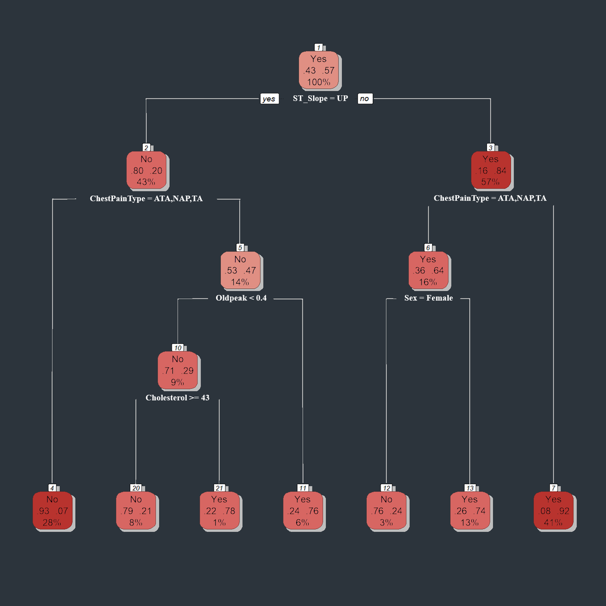

Our decision tree consists of several parts. The box on the top/`Up ST_Slope` is the **root node**. The root will split and make branches by certain rules. Each branches ended with a **node**. Then the node split again into other **nodes** that called as **internal node**. Nodes that do not split anymore appear at the very bottom of our plot which is called **terminal node** or **leaf node**. All in all, in summary, each node shows:

➢ Predicted class (`Yes` or `No`)

➢ Predicted class probabilities.

➢ Percentage of observations in the node.

➢ **Root, internal, and terminal nodes** along with the rules that partition with each observation.

### Predicting

Now we already have our model, we can continue to predict with our *test dataset*.

```r
dtree_pred <- predict(model_dtree, heart_test_tree, type = "class")
dtree_prob <- predict(model_dtree, heart_test_tree, type = "prob")
dtree_pred_t <- predict(model_dtree, heart_train_tree, type = "class")

dtree_table <- select(heart_test_tree, HeartDisease) %>%
  bind_cols(heart_pred = dtree_pred) %>%
  bind_cols(heart_eprob = round(dtree_prob[,1],4)) %>%
  bind_cols(heart_pprob = round(dtree_prob[,2],4))

dtree_table <- dtree_table %>%
  mutate(HeartDisease = as.factor(HeartDisease))

rmarkdown::paged_table(head(dtree_table, 10))
```

|  | HeartDisease | heart_pred | heart_eprob | heart_pprob |
| --- | --- | --- | --- | --- |
| 1 | 0 | 0 | 0.9330 | 0.0670 |
| 2 | 1 | 1 | 0.2604 | 0.7396 |
| 3 | 0 | 1 | 0.2604 | 0.7396 |
| 4 | 0 | 0 | 0.9330 | 0.0670 |
| 5 | 0 | 0 | 0.9330 | 0.0670 |
| 6 | 1 | 1 | 0.2604 | 0.7396 |
| 7 | 1 | 1 | 0.0805 | 0.9195 |
| 8 | 0 | 0 | 0.9330 | 0.0670 |
| 9 | 0 | 0 | 0.9330 | 0.0670 |
| 10 | 0 | 0 | 0.9330 | 0.0670 |

## Naive Bayes

**Naive Bayes** algorithm is a supervised learning algorithm which is based on **Bayes theorem** and used for solving *classification problem*. It is one of the simple and most effective Classification algorithm which helps in building the fast machine learning models that can make quick prediction.

To understand **Naive Bayes**, here is the equation:

$$P(A|B) = \frac{P(B|A)P(A)}{P(B)}$$

- **P(A|B)** is *posterior probability*: Probability of hypthesis A on the observed event B.
- **P(B|A)** is *likelihood probability*: Probability of the evidence given that the probability of a hypothesis is true.

### Cross Validation

```r
heart_nb <- heart %>%
  mutate(HeartDisease = as.factor(HeartDisease))

RNGkind(sample.kind = "Rounding")
set.seed(417)
index <- sample(nrow(heart_nb), size = nrow(heart_nb)*0.80)
heart_nb_train <- heart_nb[index,] #take 80%
heart_nb_test <- heart_nb[-index,] #take 20%

head(heart_nb)
```

```
##   Age    Sex ChestPainType RestingBP Cholesterol   FastingBS RestingECG MaxHR
## 1  40   Male           ATA       140         289 < 120 mg/dl     Normal   172
## 2  49 Female           NAP       160         180 < 120 mg/dl     Normal   156
## 3  37   Male           ATA       130         283 < 120 mg/dl         ST    98
## 4  48 Female           ASY       138         214 < 120 mg/dl     Normal   108
## 5  54   Male           NAP       150         195 < 120 mg/dl     Normal   122
## 6  39   Male           NAP       120         339 < 120 mg/dl     Normal   170
##   ExerciseAngina Oldpeak ST_Slope HeartDisease
## 1             No     0.0       Up            0
## 2             No     1.0     Flat            1
## 3             No     0.0       Up            0
## 4            Yes     1.5     Flat            1
## 5             No     0.0       Up            0
## 6             No     0.0       Up            0
```

- Re-check **class balance**:

```r
proptrain <- paste(round(prop.table((table(heart_nb_train$HeartDisease)))*100,2),"%")
proptraindf <- data.frame(HeartDisease = c("No","Yes"), Prop = c(proptrain[1], proptrain[2]))
rmarkdown::paged_table(proptraindf)
```

| HeartDisease | Prop |
| --- | --- |
| No | 43.46 % |
| Yes | 56.54 % |

As shown above, the **proportion** of the class is still balanced.

### Modelling & Fitting

```r
library(e1071)
model_nb <- naiveBayes(formula = HeartDisease~. , data = heart_nb_train, laplace = 1)
model_nb
```

```
##
## Naive Bayes Classifier for Discrete Predictors
##
## Call:
## naiveBayes.default(x = X, y = Y, laplace = laplace)
##
## A-priori probabilities:
## Y
##         0         1
## 0.4346049 0.5653951
##
## Conditional probabilities:
##    Age
## Y       [,1]     [,2]
##   0 50.26959 9.389680
##   1 56.04578 9.055402
##
##    Sex
## Y      Female      Male
##   0 0.3667712 0.6394984
##   1 0.1036145 0.9012048
##
##    ChestPainType
## Y          ASY        ATA        NAP         TA
##   0 0.25077399 0.35603715 0.31888545 0.07430341
##   1 0.77565632 0.04534606 0.13603819 0.04295943
##
##    RestingBP
## Y       [,1]     [,2]
##   0 130.1755 16.17807
##   1 134.5205 20.36073
##
##    Cholesterol
## Y       [,1]      [,2]
##   0 227.3386  72.73644
##   1 177.5060 126.58521
##
##    FastingBS
## Y   < 120 mg/dl > 120 mg/dl
##   0   0.8996865   0.1065831
```

[output cut: 11 more lines]

```
##
##    ExerciseAngina
## Y          No       Yes
##   0 0.8840125 0.1222571
##   1 0.3686747 0.6361446
##
##    Oldpeak
## Y        [,1]      [,2]
##   0 0.3971787 0.7017217
##   1 1.3159036 1.1603921
##
##    ST_Slope
## Y        Down      Flat        Up
##   0 0.0310559 0.1863354 0.7826087
##   1 0.1004785 0.7440191 0.1555024
```

Interpretation of the result above:

➢`Male Gender` has higher probability for getting a **Heart Disease Condition** (90%) and 63% more for **not** getting a **Heart Disease Condition** rather than `Female`.

➢ `ASY Chest Pain` has the highest probability for getting a **Heart Disease Condition** (77%) while `ATA Chest Pain` has the highest probability (35%) for **not** getting a **Heart Disease Condition** rather than its counterparts.

➢ Patient with `Fasting Blood Sugar < 120mg` has higher probability for getting a **Heart Disease Condition** (67%) and 89% more for **not** getting a **Heart Disease Condition** rather than patient with `Fasting Blood Sugar > 120mg`.

➢ Patient with `Normal Resting ECG` has higher probability for getting a **Heart Disease Condition** (55%) and 65% more for **not** getting a **Heart Disease Condition** rather than its counterparts.

➢ Patient with `Exercise Angina` has higher probability for getting a **Heart Disease Condition** (63%) while Patient without `Exercise Angina` is 88% more for **not** getting a **Heart Disease Condition**.

➢ `Flat ST Slope` has the highest probability for getting a **Heart Disease Condition** (74%) while `UP ST Slope` has the highest probability (78%) for **not** getting a **Heart Disease Condition** rather than its counterparts.

### Predicting

```r
naive_pred <- predict(model_nb, heart_nb_test, type = "class")
naive_prob <- predict(model_nb, heart_nb_test, type = "raw")
naive_pred_t <- predict(model_nb, heart_nb_train, type = "class")

naive_table <- select(heart_nb_test, HeartDisease) %>%
  bind_cols(heart_pred = naive_pred) %>%
  bind_cols(heart_eprob = round(naive_prob[,1],4)) %>%
  bind_cols(heart_pprob = round(naive_prob[,2],4))

naive_table <- naive_table %>%
  mutate(HeartDisease = as.factor(HeartDisease))

rmarkdown::paged_table(head(naive_table, 10))
```

|  | HeartDisease | heart_pred | heart_eprob | heart_pprob |
| --- | --- | --- | --- | --- |
| 1 | 0 | 0 | 0.9755 | 0.0245 |
| 2 | 1 | 1 | 0.0055 | 0.9945 |
| 3 | 0 | 0 | 0.9538 | 0.0462 |
| 4 | 0 | 0 | 0.9960 | 0.0040 |
| 5 | 0 | 0 | 0.9985 | 0.0015 |
| 6 | 1 | 1 | 0.0462 | 0.9538 |
| 7 | 1 | 1 | 0.0282 | 0.9718 |
| 8 | 0 | 0 | 0.9998 | 0.0002 |
| 9 | 0 | 0 | 0.9983 | 0.0017 |
| 10 | 0 | 0 | 0.9991 | 0.0009 |

# Evaluation

For **Evaluation**, we are going to use **confusionMatrix** and **ROC/AUC** function that can generate:

**Accuracy**:
$$\frac {TP + TN} {TP + TN + FP + FN}$$

**Sensitivity**:
$$\frac {TP} {TP + FN}$$

**Specificity**:
$$\frac {TN} {TN + FP}$$

**Precision**:
$$\frac {TP} {TP + FP}$$

## Logistic Regression

**EVALUATION SUMMARY**

```r
con_mat_log <- confusionMatrix(data = heart_log_test$pred_Label,
                               reference = heart_log_test$HeartDisease,
                               positive = "1")

con_mat_log_t <- confusionMatrix(data = as.factor(heart_log_train$pred_Label),
                                 reference = heart_log_train$HeartDisease,
                                 positive = "1")

performance <- cbind.data.frame(Accuracy = c(con_mat_log_t$overall[[1]], con_mat_log$overall[[1]]),
                                Sensitivity = c(con_mat_log_t$byClass[[1]], con_mat_log$byClass[[1]]),
                                Specificity = c(con_mat_log_t$byClass[[2]], con_mat_log$byClass[[2]]),
                                Precision = c(con_mat_log_t$byClass[[3]], con_mat_log$byClass[[3]]))

rownames(performance) <- c("On Training Data", "On Unseen Data")

rmarkdown::paged_table(performance)
```

|  | Accuracy | Sensitivity | Specificity | Precision |
| --- | --- | --- | --- | --- |
| On Training Data | 0.8732970 | 0.9012048 | 0.8369906 | 0.8779343 |
| On Unseen Data | 0.8315217 | 0.8709677 | 0.7912088 | 0.8100000 |

➢ There are no big differences between our Accuracy, Sensitivity, Specificity, and Precision score on the Unseen and Training Data.

➢ This means that there are no indication of **Overfitting and Underfitting** for our **Logistic Regression** model.

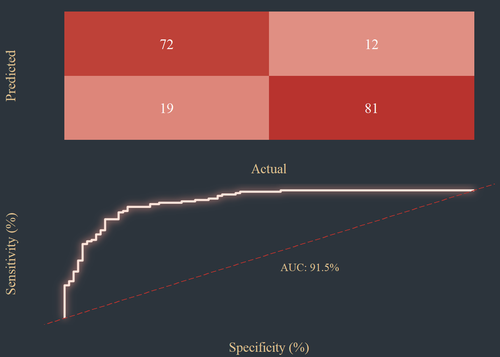

```r
Actual <- factor(c("No", "No", "Yes", "Yes"))
Predicted <- factor(c("No", "Yes", "No", "Yes"))
y      <- c(con_mat_log$table[2], con_mat_log$table[1], con_mat_log$table[4], con_mat_log$table[3])
df1_log <- data.frame(Actual, Predicted, y)

roc <-  roc(predictor = heart_log_test$pred_Risk,
            response = heart_log_test$HeartDisease,
            levels = c("0", "1"),
            percent = TRUE)
df2_log <-  data.frame(Specificity=roc$specificities, Sensitivity=roc$sensitivities)

plot_log1 <- ggplot(data =  df1_log, mapping = aes(x = Actual, y = Predicted, col = y)) +
  geom_tile(aes(fill = y)) +
  geom_text(aes(label = sprintf("%1.0f", y)), color = "White", size = 5, family = "Times New Roman") +
  scale_fill_gradient(low = "#E08F83", high = "#B8332E") +
  scale_color_gradient(low = "#E08F83", high = "#B8332E") +
  theme(legend.position = "none",
        plot.background = element_rect(fill = "#2C343C", color = "#2C343C"),
        panel.background = element_rect(fill = "#2C343C"),
        panel.grid = element_line(colour = "#2C343C"),
        panel.grid.major.x = element_line(colour = "#2C343C"),
        panel.grid.minor.x = element_line(colour = "#2C343C"),
        axis.text.x = element_text(color = "#2C343C", family = "Times New Roman", size = 14),
        axis.text.y = element_text(color = "#2C343C", family = "Times New Roman", size = 14),
        axis.title.x = element_text(color = "#DFC18F", family = "Times New Roman", size = 14),
        axis.title.y = element_text(color = "#DFC18F", family = "Times New Roman", size = 14),
        axis.ticks = element_blank())

plot_log2 <- ggplot(data = df2_log, aes(x = Specificity, y = Sensitivity))+
  with_outer_glow(geom_path(colour = '#FFE5DB', size = 1), colour = "#E08F83", sigma = 10, expand = 1)+
  scale_x_reverse() +
  geom_abline(intercept = 100, slope = 1, color="#B8332E", linetype = "longdash") +
  annotate("text", x = 40, y = 40, label = paste0('AUC: ', round(roc$auc,1), '%'), size = 4, color = "#DFC18F", family = "Times New Roman")+
  ylab('Sensitivity (%)')+
  xlab('Specificity (%)')+
  scale_fill_gradient(low = "#E08F83", high = "#B8332E") +
  scale_color_gradient(low = "#E08F83", high = "#B8332E") +
  theme(legend.position = "none",
        plot.background = element_rect(fill = "#2C343C", color = "#2C343C"),
        panel.background = element_rect(fill = "#2C343C"),
        panel.grid = element_line(colour = "#2C343C"),
        panel.grid.major.x = element_line(colour = "#2C343C"),
        panel.grid.minor.x = element_line(colour = "#2C343C"),
        axis.text.x = element_text(color = "#2C343C", family = "Times New Roman", size = 14),
        axis.text.y = element_text(color = "#2C343C", family = "Times New Roman", size = 14),
        axis.title.x = element_text(color = "#DFC18F", family = "Times New Roman", size = 14),
        axis.title.y = element_text(color = "#DFC18F", family = "Times New Roman", size = 14),
        axis.ticks = element_blank())

ggarrange(plot_log1, plot_log2, nrow = 2, ncol = 1)
```

★ Our **logistic regression model** has performance accuracy of 83.15% on unseen data. Meaning that 83.15% of our data is correctly classified.

★ The value of sensitivity is 87.09% which indicates that most positive outcomes are correctly classified.

★ The value of specificity is 79.12% which indicates that most negative outcomes are correctly classified.

★ The value of precision is 81% which indicates that 81% of our positive prediction is correct.

★ Our ROC Curve also shows a very good separation with AUC score of 91.5%. Meaning that our model is proven to be near excellent at separating our **target classes**.

## K-NN

**EVALUATION SUMMARY**

```r
con_mat_knn <- confusionMatrix(data = heartknn_pred,
                               reference = heartknn_test_y$HeartDisease,
                               positive = "1")

con_mat_knn_t <- confusionMatrix(data = heartknn_pred_t,
                               reference = heartknn_train_y$HeartDisease,
                               positive = "1")

performanceknn <- cbind.data.frame(Accuracy = c(con_mat_knn_t$overall[[1]], con_mat_knn$overall[[1]]),
                                Sensitivity = c(con_mat_knn_t$byClass[[1]], con_mat_knn$byClass[[1]]),
                                Specificity = c(con_mat_knn_t$byClass[[2]], con_mat_knn$byClass[[2]]),
                                Precision = c(con_mat_knn_t$byClass[[3]], con_mat_knn$byClass[[3]]))

rownames(performanceknn) <- c("On Training Data", "On Unseen Data")

rmarkdown::paged_table(performanceknn)
```

|  | Accuracy | Sensitivity | Specificity | Precision |
| --- | --- | --- | --- | --- |
| On Training Data | 0.7288828 | 0.7915633 | 0.6525680 | 0.7350230 |
| On Unseen Data | 0.7500000 | 0.8285714 | 0.6455696 | 0.7565217 |

➢ There are no big differences between our Accuracy, Sensitivity, Specificity, and Precision score on the Unseen and Training Data.

➢ This means that there are no indication of **Overfitting and Underfitting** for our **K-NN** model.

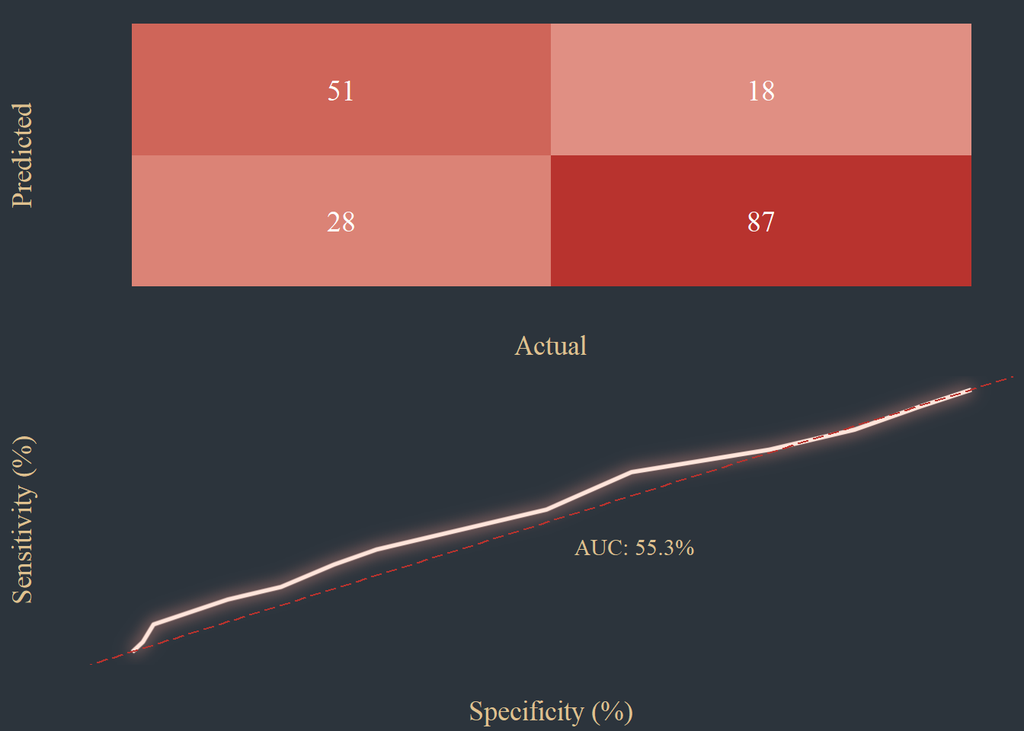

```r
Actual1 <- factor(c("No", "No", "Yes", "Yes"))
Predicted1 <- factor(c("No", "Yes", "No", "Yes"))
y1      <- c(con_mat_knn$table[2], con_mat_knn$table[1], con_mat_knn$table[4], con_mat_knn$table[3])
df1_knn <- data.frame(Actual1, Predicted1, y1)

roc1 <- roc(predictor = attributes(heartknn_pred)$prob,
            response = heartknn_test_y$HeartDisease,
            levels = c("0", "1"),
            percent = TRUE)

df2_knn <- data.frame(Specificity=roc1$specificities, Sensitivity=roc1$sensitivities)

plot_knn1 <- ggplot(data =  df1_knn, mapping = aes(x = Actual1, y = Predicted1, col = y1)) +
  geom_tile(aes(fill = y1)) +
  geom_text(aes(label = sprintf("%1.0f", y1)), color = "White", size = 5, family = "Times New Roman") +
  scale_fill_gradient(low = "#E08F83", high = "#B8332E") +
  scale_color_gradient(low = "#E08F83", high = "#B8332E") +
  labs(x = "Actual",
       y = "Predicted") +
  theme(legend.position = "none",
        plot.background = element_rect(fill = "#2C343C", color = "#2C343C"),
        panel.background = element_rect(fill = "#2C343C"),
        panel.grid = element_line(colour = "#2C343C"),
        panel.grid.major.x = element_line(colour = "#2C343C"),
        panel.grid.minor.x = element_line(colour = "#2C343C"),
        axis.text.x = element_text(color = "#2C343C", family = "Times New Roman", size = 14),
        axis.text.y = element_text(color = "#2C343C", family = "Times New Roman", size = 14),
        axis.title.x = element_text(color = "#DFC18F", family = "Times New Roman", size = 14),
        axis.title.y = element_text(color = "#DFC18F", family = "Times New Roman", size = 14),
        axis.ticks = element_blank())

plot_knn2 <- ggplot(data = df2_knn, aes(x = Specificity, y = Sensitivity))+
  with_outer_glow(geom_path(colour = '#FFE5DB', size = 1), colour = "#E08F83", sigma = 10, expand = 1)+
  scale_x_reverse() +
  geom_abline(intercept = 100, slope = 1, color="#B8332E", linetype = "longdash") +
  annotate("text", x = 40, y = 40, label = paste0('AUC: ', round(roc1$auc,1), '%'), size = 4, color = "#DFC18F", family = "Times New Roman")+
  ylab('Sensitivity (%)')+
  xlab('Specificity (%)')+
  scale_fill_gradient(low = "#E08F83", high = "#B8332E") +
  scale_color_gradient(low = "#E08F83", high = "#B8332E") +
  theme(legend.position = "none",
        plot.background = element_rect(fill = "#2C343C", color = "#2C343C"),
        panel.background = element_rect(fill = "#2C343C"),
        panel.grid = element_line(colour = "#2C343C"),
        panel.grid.major.x = element_line(colour = "#2C343C"),
        panel.grid.minor.x = element_line(colour = "#2C343C"),
        axis.text.x = element_text(color = "#2C343C", family = "Times New Roman", size = 14),
        axis.text.y = element_text(color = "#2C343C", family = "Times New Roman", size = 14),
        axis.title.x = element_text(color = "#DFC18F", family = "Times New Roman", size = 14),
        axis.title.y = element_text(color = "#DFC18F", family = "Times New Roman", size = 14),
        axis.ticks = element_blank())

ggarrange(plot_knn1, plot_knn2, nrow = 2, ncol = 1)
```

★ Our **K-NN model** has performance accuracy of 75% on unseen data. Meaning that 75% of our data is correctly classified.

★ The value of sensitivity is 82.85% which indicates that most positive outcomes are correctly classified.

★ The value of specificity is 64.55% which indicates that only moderate negative outcomes are correctly classified.

★ The value of precision is 75.65% which indicates that 75.65% of our positive prediction is correct.

★ Our ROC Curve also shows a bad performance of separation with AUC score of 55.3%. Meaning that if we want to use this model, we have to tune the model until we get a better score results than the other model.

## Decision Tree

**EVALUATION SUMMARY**

```r
con_mat_dt <- confusionMatrix(data = dtree_table$heart_pred,
                              reference = dtree_table$HeartDisease,
                              positive = "1")

con_mat_dt_t <- confusionMatrix(data = dtree_pred_t,
                                reference = as.factor(heart_train_tree$HeartDisease),
                                positive = "1")

performance_dt <- cbind.data.frame(Accuracy = c(con_mat_dt_t$overall[[1]], con_mat_dt$overall[[1]]),
                                   Sensitivity = c(con_mat_dt_t$byClass[[1]], con_mat_dt$byClass[[1]]),
                                   Specificity = c(con_mat_dt_t$byClass[[2]], con_mat_dt$byClass[[2]]),
                                   Precision = c(con_mat_dt_t$byClass[[3]], con_mat_dt$byClass[[3]]))

rownames(performance_dt) <- c("On Training Data", "On Unseen Data")

rmarkdown::paged_table(performance_dt)
```

|  | Accuracy | Sensitivity | Specificity | Precision |
| --- | --- | --- | --- | --- |
| On Training Data | 0.8732970 | 0.9228916 | 0.8087774 | 0.8626126 |
| On Unseen Data | 0.8206522 | 0.8924731 | 0.7472527 | 0.7830189 |

➢ There are no big differences between our Accuracy, Sensitivity, Specificity, and Precision score on the Unseen and Training Data.

➢ This means that there are no indication of **Overfitting and Underfitting** for our **Decision Tree** model.

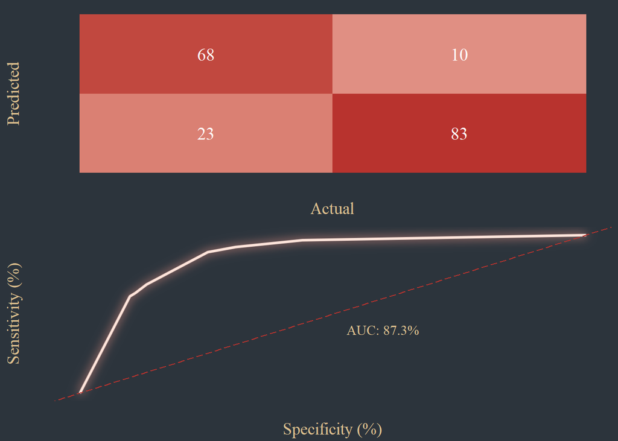

```r
Actual2 <- factor(c("No", "No", "Yes", "Yes"))
Predicted2 <- factor(c("No", "Yes", "No", "Yes"))
y2      <- c(con_mat_dt$table[2], con_mat_dt$table[1], con_mat_dt$table[4], con_mat_dt$table[3])
df1_dt <- data.frame(Actual2, Predicted2, y2)

roc2 <- roc(predictor = dtree_table$heart_eprob,
            response = dtree_table$HeartDisease,
            levels = c("0", "1"),
            percent = TRUE)

df2_dt <- data.frame(Specificity=roc2$specificities, Sensitivity=roc2$sensitivities)

plot_dt <- ggplot(data =  df1_dt, mapping = aes(x = Actual2, y = Predicted2, col = y2)) +
  geom_tile(aes(fill = y2)) +
  geom_text(aes(label = sprintf("%1.0f", y2)), color = "White", size = 5, family = "Times New Roman") +
  scale_fill_gradient(low = "#E08F83", high = "#B8332E") +
  scale_color_gradient(low = "#E08F83", high = "#B8332E") +
  labs(x = "Actual",
       y = "Predicted") +
  theme(legend.position = "none",
        plot.background = element_rect(fill = "#2C343C", color = "#2C343C"),
        panel.background = element_rect(fill = "#2C343C"),
        panel.grid = element_line(colour = "#2C343C"),
        panel.grid.major.x = element_line(colour = "#2C343C"),
        panel.grid.minor.x = element_line(colour = "#2C343C"),
        axis.text.x = element_text(color = "#2C343C", family = "Times New Roman", size = 14),
        axis.text.y = element_text(color = "#2C343C", family = "Times New Roman", size = 14),
        axis.title.x = element_text(color = "#DFC18F", family = "Times New Roman", size = 14),
        axis.title.y = element_text(color = "#DFC18F", family = "Times New Roman", size = 14),
        axis.ticks = element_blank())

plot_dt2 <- ggplot(data = df2_dt, aes(x = Specificity, y = Sensitivity))+
  with_outer_glow(geom_path(colour = '#FFE5DB', size = 1), colour = "#E08F83", sigma = 10, expand = 1)+
  scale_x_reverse() +
  geom_abline(intercept = 100, slope = 1, color="#B8332E", linetype = "longdash") +
  annotate("text", x = 40, y = 40, label = paste0('AUC: ', round(roc2$auc,1), '%'), size = 4, color = "#DFC18F", family = "Times New Roman")+
  ylab('Sensitivity (%)')+
  xlab('Specificity (%)')+
  scale_fill_gradient(low = "#E08F83", high = "#B8332E") +
  scale_color_gradient(low = "#E08F83", high = "#B8332E") +
  theme(legend.position = "none",
        plot.background = element_rect(fill = "#2C343C", color = "#2C343C"),
        panel.background = element_rect(fill = "#2C343C"),
        panel.grid = element_line(colour = "#2C343C"),
        panel.grid.major.x = element_line(colour = "#2C343C"),
        panel.grid.minor.x = element_line(colour = "#2C343C"),
        axis.text.x = element_text(color = "#2C343C", family = "Times New Roman", size = 14),
        axis.text.y = element_text(color = "#2C343C", family = "Times New Roman", size = 14),
        axis.title.x = element_text(color = "#DFC18F", family = "Times New Roman", size = 14),
        axis.title.y = element_text(color = "#DFC18F", family = "Times New Roman", size = 14),
        axis.ticks = element_blank())

ggarrange(plot_dt, plot_dt2, nrow = 2, ncol = 1)
```

★ Our **Decision Tree model** has performance accuracy of 82.06% on unseen data. Meaning that 82.06% of our data is correctly classified.

★ The value of sensitivity is 89.24% which indicates that most positive outcomes are correctly classified.

★ The value of specificity is 74.72% which indicates that moderate number of negative outcomes are correctly classified.

★ Our ROC Curve also shows a very good separation with AUC score of 87.3%. Meaning that our model is already good at separating our **target classes**.

## Naive Bayes

**EVALUATION SUMMARY**

```r
con_mat_nb <- confusionMatrix(data = naive_table$heart_pred,
                              reference = naive_table$HeartDisease,
                              positive = "1")

con_mat_nb_t <- confusionMatrix(data = naive_pred_t,
                                reference = as.factor(heart_nb_train$HeartDisease),
                                positive = "1")

performance_nb <- cbind.data.frame(Accuracy = c(con_mat_nb_t$overall[[1]], con_mat_nb$overall[[1]]),
                                  Sensitivity = c(con_mat_nb_t$byClass[[1]], con_mat_nb$byClass[[1]]),
                                  Specificity = c(con_mat_nb_t$byClass[[2]], con_mat_nb$byClass[[2]]),
                                  Precision = c(con_mat_nb_t$byClass[[3]], con_mat_nb$byClass[[3]]))

rownames(performance_nb) <- c("On Training Data", "On Unseen Data")

rmarkdown::paged_table(performance_nb)
```

|  | Accuracy | Sensitivity | Specificity | Precision |
| --- | --- | --- | --- | --- |
| On Training Data | 0.8719346 | 0.8891566 | 0.8495298 | 0.8848921 |
| On Unseen Data | 0.8097826 | 0.8709677 | 0.7472527 | 0.7788462 |

➢ There are no big differences between our Accuracy, Sensitivity, Specificity, and Precision score on the Unseen and Training Data.

➢ This means that there are no indication of **Overfitting and Underfitting** for our **Naive Bayes** model.

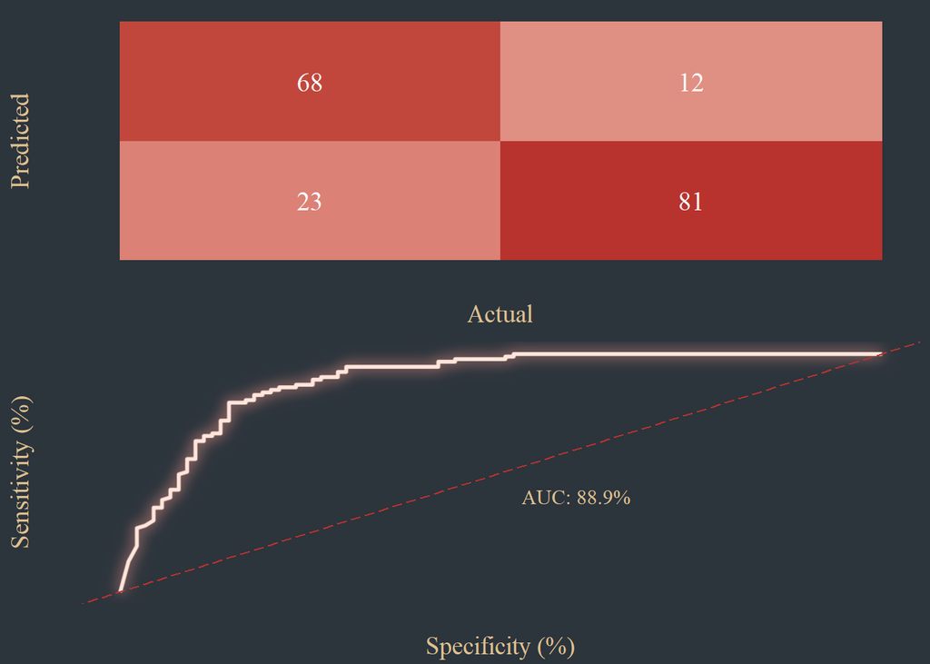

```r
Actual3 <- factor(c("No", "No", "Yes", "Yes"))
Predicted3 <- factor(c("No", "Yes", "No", "Yes"))
y3      <- c(con_mat_nb$table[2], con_mat_nb$table[1], con_mat_nb$table[4], con_mat_nb$table[3])
df1_nb <- data.frame(Actual3, Predicted3, y3)

roc3 <- roc(predictor = naive_table$heart_eprob,
            response = naive_table$HeartDisease,
            levels = c("0","1"),
            percent = TRUE)

df2_nb <-  data.frame(Specificity=roc3$specificities, Sensitivity=roc3$sensitivities)

plot_nb <- ggplot(data =  df1_nb, mapping = aes(x = Actual3, y = Predicted3, col = y3)) +
  geom_tile(aes(fill = y3)) +
  geom_text(aes(label = sprintf("%1.0f", y3)), color = "White", size = 5, family = "Times New Roman") +
  scale_fill_gradient(low = "#E08F83", high = "#B8332E") +
  scale_color_gradient(low = "#E08F83", high = "#B8332E") +
  labs(x = "Actual",
       y = "Predicted") +
  theme(legend.position = "none",
        plot.background = element_rect(fill = "#2C343C", color = "#2C343C"),
        panel.background = element_rect(fill = "#2C343C"),
        panel.grid = element_line(colour = "#2C343C"),
        panel.grid.major.x = element_line(colour = "#2C343C"),
        panel.grid.minor.x = element_line(colour = "#2C343C"),
        axis.text.x = element_text(color = "#2C343C", family = "Times New Roman", size = 14),
        axis.text.y = element_text(color = "#2C343C", family = "Times New Roman", size = 14),
        axis.title.x = element_text(color = "#DFC18F", family = "Times New Roman", size = 14),
        axis.title.y = element_text(color = "#DFC18F", family = "Times New Roman", size = 14),
        axis.ticks = element_blank())

plot_nb2 <- ggplot(data = df2_nb, aes(x = Specificity, y = Sensitivity))+
  with_outer_glow(geom_path(colour = '#FFE5DB', size = 1), colour = "#E08F83", sigma = 10, expand = 1)+
  scale_x_reverse() +
  geom_abline(intercept = 100, slope = 1, color="#B8332E", linetype = "longdash") +
  annotate("text", x = 40, y = 40, label = paste0('AUC: ', round(roc3$auc,1), '%'), size = 4, color = "#DFC18F", family = "Times New Roman")+
  ylab('Sensitivity (%)')+
  xlab('Specificity (%)')+
  scale_fill_gradient(low = "#E08F83", high = "#B8332E") +
  scale_color_gradient(low = "#E08F83", high = "#B8332E") +
  theme(legend.position = "none",
        plot.background = element_rect(fill = "#2C343C", color = "#2C343C"),
        panel.background = element_rect(fill = "#2C343C"),
        panel.grid = element_line(colour = "#2C343C"),
        panel.grid.major.x = element_line(colour = "#2C343C"),
        panel.grid.minor.x = element_line(colour = "#2C343C"),
        axis.text.x = element_text(color = "#2C343C", family = "Times New Roman", size = 14),
        axis.text.y = element_text(color = "#2C343C", family = "Times New Roman", size = 14),
        axis.title.x = element_text(color = "#DFC18F", family = "Times New Roman", size = 14),
        axis.title.y = element_text(color = "#DFC18F", family = "Times New Roman", size = 14),
        axis.ticks = element_blank())

ggarrange(plot_nb, plot_nb2, nrow = 2, ncol = 1)
```

★ Our **Naive Bayes model** has performance accuracy of 80.9% on unseen data. Meaning that 80.90% of our data is correctly classified.

★ The value of sensitivity is 87.09% which indicates that most positive outcomes are correctly classified.

★ The value of specificity is 74.72% which indicates that moderate number of negative outcomes are correctly classified.

★ The value of precision is 77.9% which indicates that 77.9% of our positive prediction is correct.

★ Our ROC Curve also shows a very good separation with AUC score of 88.9%. Meaning that our model is already good at separating our **target classes**.

# Conclusion

Since we’re talking about **Health diagnosis prediction**, we want to minimize our error on positive outcomes prediction. Which in our case is about patient with **Heart Disease Condition**. Hereby if we look at our model performance evaluation, we want to use a model with a good score of sensitivity.

And that’s all my attempt to classify **Heart Disease** with **Classification Models**. As time goes by, I will add more **models** who are not covered yet in this project. However, I sincerely hope that this study could help people who will do some similar cases in the future.

A work by [Rangga Gemilang](https://github.com/RanggaGemilang)

*gemilang.rangga94@gmail.com*

*R Language*